# Supplementary Material: Fertility Rates Article

Rafael Sant’Ana Herzog

2025-05-01

# Introduction

This document aims to detail all the analyses conducted for the article “Fertility rate among adolescents in Brazil in the period 2012-2021: effects of human development, primary care coverage and the COVID-19 pandemic”, providing additional context to the results shown in the paper.

# Importing the necessary packages

```r
library(knitr)
library(kableExtra)
library(reactable)
library(dplyr)
library(tidyr)
library(ggplot2)
library(trend)
library(factoextra)
library(clusterSim)
library(clValid)
library(htmltools)
library(gridExtra)
library(grid)
library(rstatix)
library(sf)
library(geobr)
library(corrplot)
library(gamlss)
```

# About the dataset

```r
# Importing the dataset
df_indicadores <- read.csv("databases/data_fertility_rates_article.csv") |>
  mutate(regiao = factor(regiao, levels = c("Norte", "Nordeste", "Centro-Oeste", "Sudeste", "Sul")))
```

## Variables description

The dataset used in this study included variables available on several different databases. To obtain the variables from SINASC (more specifically, the number of births of mothers in each age group), we used the `{microdatasus}` package in R. To obtain the population estimates for each age group, we used [Tabnet DATASUS](http://tabnet.datasus.gov.br/cgi/deftohtm.exe?ibge/cnv/popsvs2024br.def) (using the updated estimates after the 2022 census). To obtain the number of women beneficiaries of private health plans (used for calculating the percentage of women who exclusively use the SUS), we used [Tabnet ANS](https://www.ans.gov.br/anstabnet/cgi-bin/dh?dados/tabnet_02.def). To obtain the variables used to calculate the Primary Care coverage, we used the “e-Gestor Atenção Primária à Saúde” platform. Finally, to obtain the HDI-M, we used [Atlas Brasil](http://www.atlasbrasil.org.br/). All data was obtained for the period 2012 to 2021. A table describing the variables included in the file `data_fertility_rates_article.csv` can be seen below.

Table 1: Description of the variables in the dataset.

| Variable | Description | Source |
| --- | --- | --- |
| codmunres | Municipality code | SINASC |
| municipio | Municipality name | SINASC |
| uf | Federative Unit | SINASC |
| regiao | Brazilian Region | SINASC |
| ano | Year | — |
| nvm_10_a_14 | Live births of mothers aged 10 to 14 years | SINASC |
| nvm_15_a_19 | Live births of mothers aged 15 to 19 years | SINASC |
| nvm_10_a_19 | Live births of mothers aged 10 to 19 years | SINASC |
| pop_feminina_10_a_14 | Estimated female population aged 10 to 14 years | Tabnet DATASUS |
| pop_feminina_15_a_19 | Estimated female population aged 15 to 19 years | Tabnet DATASUS |
| pop_feminina_10_a_19 | Estimated female population aged 10 to 19 years | Tabnet DATASUS |
| pop_feminina_10_a_49 | Estimated female population aged 10 to 49 years | Tabnet DATASUS |
| idhm | HDI-M | Atlas Brasil |
| media_cobertura_ab | Population covered by Primary Care teams | e-Gestor Atenção Primária à Saúde |
| populacao_total | Total population | e-Gestor Atenção Primária à Saúde |
| pop_fem_10_49_com_plano_saude | Female population aged 10 to 49 years with private health insurance | Tabnet ANS |

## Missing data

The only variable in the data set that contained missing information was the HDI-M. The five municipalities with missing HDI-M were removed from the dataset only for the modeling phase.

```r
# Checking for NAs
colSums(is.na(df_indicadores))
```

```
##                     codmunres                     municipio
##                             0                             0
##                            uf                        regiao
##                             0                             0
##                           ano                   nvm_10_a_14
##                             0                             0
##                   nvm_15_a_19                   nvm_10_a_19
##                             0                             0
##          pop_feminina_10_a_14          pop_feminina_15_a_19
##                             0                             0
##          pop_feminina_10_a_19          pop_feminina_10_a_49
##                             0                             0
##                          idhm            media_cobertura_ab
##                            50                             0
##               populacao_total pop_fem_10_49_com_plano_saude
##                             0                             0
```

```r
# Checking which municipalities had missing HDI-M
unique(df_indicadores$municipio[is.na(df_indicadores$idhm)])
```

```
## [1] "Mojuí dos Campos"  "Pescaria Brava"    "Balneário Rincão"
## [4] "Pinto Bandeira"    "Paraíso das Águas"
```

## Municipalities with no births

All the years in the considered period included municipalities that had no births from mothers in each age group.

```r
# Checking how many municipalities had 0 births from mothers in each age group per year
df_indicadores |>
  group_by(ano) |>
  summarise(
    municipalities_zero_births_10_to_14 = sum(nvm_10_a_14 == 0, na.rm = TRUE),
    municipalities_zero_births_15_to_19 = sum(nvm_15_a_19 == 0, na.rm = TRUE),
    municipalities_zero_births_10_to_19 = sum(nvm_10_a_19 == 0, na.rm = TRUE)
  ) |>
  ungroup() |>
  kable()
```

| ano | municipalities_zero_births_10_to_14 | municipalities_zero_births_15_to_19 | municipalities_zero_births_10_to_19 |
| --- | --- | --- | --- |
| 2012 | 1704 | 37 | 36 |
| 2013 | 1754 | 42 | 40 |
| 2014 | 1735 | 40 | 39 |
| 2015 | 1781 | 34 | 34 |
| 2016 | 1860 | 46 | 43 |
| 2017 | 1945 | 57 | 52 |
| 2018 | 2010 | 45 | 39 |
| 2019 | 2116 | 59 | 58 |
| 2020 | 2212 | 66 | 59 |
| 2021 | 2196 | 80 | 76 |

In addition, 227 municipalities had no births from mothers aged 10 to 14 in the entire period.

```r
# Checking how many municipalities had 0 births in the whole period for each age group
df_indicadores |>
  group_by(codmunres) |>
  summarise(
    all_zeros_10_to_14 = all(nvm_10_a_14 == 0, na.rm = TRUE),
    all_zeros_15_to_19 = all(nvm_15_a_19 == 0, na.rm = TRUE),
    all_zeros_10_to_19 = all(nvm_10_a_19 == 0, na.rm = TRUE)
  ) |>
  summarise(
    municipalities_with_all_zeros_10_to_14 = sum(all_zeros_10_to_14),
    municipalities_with_all_zeros_15_to_19 = sum(all_zeros_15_to_19),
    municipalities_with_all_zeros_10_to_19 = sum(all_zeros_10_to_19)
  ) |>
  kable()
```

| municipalities_with_all_zeros_10_to_14 | municipalities_with_all_zeros_15_to_19 | municipalities_with_all_zeros_10_to_19 |
| --- | --- | --- |
| 227 | 0 | 0 |

In an attempt to take into account factors such as under-registration of the number of live births in small municipalities, we corrected the numbers of live births using the SINASC under-registration estimates provided by the [IBGE](https://www.ibge.gov.br/estatisticas/sociais/populacao/26176-estimativa-do-sub-registro.html). Despite a small decrease in the number of municipalities that did not report births in each age group, as we can see from the output below, we decided not to use this approach because: 1) under-registration estimates are only available from 2015 onwards, making it impossible to correct the temporal analyses in this article, which consider the entire period from 2012 to 2021; 2) not all municipalities contained under-registration estimates; and 3) even for the analyses in which we could make this correction for the entire period considered (i.e the cluster analyses and modeling), new fitting attempts revealed that the correction had minimal influence on the results - for the modeling, for example, the differences in the estimated coefficients were in the third decimal place. Therefore, understanding that the macro scenario was not improved after the correction, we decided to calculate the fertility rates in a raw manner, without using any additional techniques in the process.

```r
# Reading a dataset with SINASC under-registration estimates
df_cobertura_sinasc <- read.csv("databases/dados_cobertura_sinasc_2015_2021.csv")

# Adjusting the number of births according to the under-registration estimates
df_indicadores_corrigido <- df_indicadores |>
  left_join(df_cobertura_sinasc) |>
  filter(ano >= 2015) |>
  mutate(
    nvm_10_a_14_corrigido = round(nvm_10_a_14 * 100 / cobertura_sinasc),
    nvm_15_a_19_corrigido = round(nvm_15_a_19 * 100 / cobertura_sinasc),
    nvm_10_a_19_corrigido = round(nvm_10_a_19 * 100 / cobertura_sinasc)
  )
```

```r
# Checking how many municipalities had 0 births from mothers in each age group per year after the correction
df_indicadores_corrigido |>
  group_by(ano) |>
  summarise(
    municipalities_zero_births_10_to_14 = sum(nvm_10_a_14_corrigido == 0, na.rm = TRUE),
    municipalities_zero_births_15_to_19 = sum(nvm_15_a_19_corrigido == 0, na.rm = TRUE),
    municipalities_zero_births_10_to_19 = sum(nvm_10_a_19_corrigido == 0, na.rm = TRUE)
  ) |>
  ungroup() |>
  kable()
```

| ano | municipalities_zero_births_10_to_14 | municipalities_zero_births_15_to_19 | municipalities_zero_births_10_to_19 |
| --- | --- | --- | --- |
| 2015 | 1774 | 34 | 34 |
| 2016 | 1851 | 46 | 43 |
| 2017 | 1937 | 57 | 52 |
| 2018 | 2010 | 45 | 39 |
| 2019 | 2115 | 59 | 58 |
| 2020 | 2212 | 66 | 59 |
| 2021 | 2195 | 80 | 76 |

The municipalities that would be most affected by under-registration corrections for each age group can be seen in the interactive tables below (ordered, by default, by the percentage increase in the number of births).

**- For the 10 to 14 aged group:**

```r
df_indicadores_corrigido |>
  mutate(
    births_added_10_to_14 = nvm_10_a_14_corrigido - nvm_10_a_14,
    percentage_increase = round(nvm_10_a_14_corrigido / nvm_10_a_14 * 100 - 100, 1)
  ) |>
  arrange(desc(percentage_increase)) |>
  select(
    Codmunres = codmunres,
    Municipalty = municipio,
    State = uf,
    Ano = ano,
    `Original number of births (10-14)` = nvm_10_a_14,
    `Corrected number of births (10-14)` = nvm_10_a_14_corrigido,
    `Total births added (10-14)` = births_added_10_to_14,
    `% increase` = percentage_increase
  ) |>
  reactable(filterable = TRUE)
```

| Codmunres | Municipalty | State | Ano | Original number of births (10-14) | Corrected number of births (10-14) | Total births added (10-14) | % increase |
| --- | --- | --- | --- | --- | --- | --- | --- |
| 210710 | Morros | Maranhão | 2021 | 4 | 11 | 7 | 175 |
| 261270 | Santa Maria do Cambucá | Pernambuco | 2019 | 4 | 9 | 5 | 125 |
| 120043 | Santa Rosa do Purus | Acre | 2016 | 3 | 6 | 3 | 100 |
| 210237 | Cachoeira Grande | Maranhão | 2021 | 1 | 2 | 1 | 100 |
| 230360 | Catarina | Ceará | 2019 | 1 | 2 | 1 | 100 |
| 251335 | Santa Inês | Paraíba | 2015 | 1 | 2 | 1 | 100 |
| 261270 | Santa Maria do Cambucá | Pernambuco | 2020 | 2 | 4 | 2 | 100 |
| 261270 | Santa Maria do Cambucá | Pernambuco | 2021 | 2 | 4 | 2 | 100 |
| 314655 | Pai Pedro | Minas Gerais | 2017 | 1 | 2 | 1 | 100 |
| 130002 | Alvarães | Amazonas | 2016 | 10 | 19 | 9 | 90 |

[output cut: 38980 more lines]

**- For the 15 to 19 aged group:**

```r
df_indicadores_corrigido |>
  mutate(
    births_added_15_to_19 = nvm_15_a_19_corrigido - nvm_15_a_19,
    percentage_increase = round(nvm_15_a_19_corrigido / nvm_15_a_19 * 100 - 100, 1)
  ) |>
  arrange(desc(percentage_increase)) |>
  select(
    Codmunres = codmunres,
    Municipalty = municipio,
    State = uf,
    Ano = ano,
    `Original number of births (15-19)` = nvm_15_a_19,
    `Corrected number of births (15-19)` = nvm_15_a_19_corrigido,
    `Total births added (15-19)` = births_added_15_to_19,
    `% increase` = percentage_increase
  ) |>
  reactable(filterable = TRUE)
```

| Codmunres | Municipalty | State | Ano | Original number of births (15-19) | Corrected number of births (15-19) | Total births added (15-19) | % increase |
| --- | --- | --- | --- | --- | --- | --- | --- |
| 210710 | Morros | Maranhão | 2021 | 52 | 139 | 87 | 167.3 |
| 210237 | Cachoeira Grande | Maranhão | 2021 | 17 | 40 | 23 | 135.3 |
| 261270 | Santa Maria do Cambucá | Pernambuco | 2019 | 44 | 98 | 54 | 122.7 |
| 261270 | Santa Maria do Cambucá | Pernambuco | 2021 | 34 | 70 | 36 | 105.9 |
| 261270 | Santa Maria do Cambucá | Pernambuco | 2020 | 35 | 72 | 37 | 105.7 |
| 130002 | Alvarães | Amazonas | 2016 | 121 | 235 | 114 | 94.2 |
| 290440 | Brejolândia | Bahia | 2015 | 9 | 17 | 8 | 88.9 |
| 353720 | Pedro de Toledo | São Paulo | 2021 | 17 | 32 | 15 | 88.2 |
| 330050 | Bom Jardim | Rio de Janeiro | 2017 | 24 | 45 | 21 | 87.5 |
| 330160 | Duas Barras | Rio de Janeiro | 2021 | 8 | 15 | 7 | 87.5 |

[output cut: 38980 more lines]

**- For the 10 to 19 aged group:**

```r
df_indicadores_corrigido |>
  mutate(
    births_added_10_to_19 = nvm_10_a_19_corrigido - nvm_10_a_19,
    percentage_increase = round(nvm_10_a_19_corrigido / nvm_10_a_19 * 100 - 100, 1)
  ) |>
  arrange(desc(percentage_increase)) |>
  select(
    Codmunres = codmunres,
    Municipalty = municipio,
    Ano = ano,
    State = uf,
    `Original number of births (10-19)` = nvm_10_a_19,
    `Corrected number of births (10-19)` = nvm_10_a_19_corrigido,
    `Total births added (10-19)` = births_added_10_to_19,
    `% increase` = percentage_increase
  ) |>
  reactable(filterable = TRUE)
```

| Codmunres | Municipalty | Ano | State | Original number of births (10-19) | Corrected number of births (10-19) | Total births added (10-19) | % increase |
| --- | --- | --- | --- | --- | --- | --- | --- |
| 210710 | Morros | 2021 | Maranhão | 56 | 150 | 94 | 167.9 |
| 210237 | Cachoeira Grande | 2021 | Maranhão | 18 | 42 | 24 | 133.3 |
| 261270 | Santa Maria do Cambucá | 2019 | Pernambuco | 48 | 107 | 59 | 122.9 |
| 261270 | Santa Maria do Cambucá | 2021 | Pernambuco | 36 | 74 | 38 | 105.6 |
| 261270 | Santa Maria do Cambucá | 2020 | Pernambuco | 37 | 76 | 39 | 105.4 |
| 130002 | Alvarães | 2016 | Amazonas | 131 | 255 | 124 | 94.7 |
| 290440 | Brejolândia | 2015 | Bahia | 9 | 17 | 8 | 88.9 |
| 353720 | Pedro de Toledo | 2021 | São Paulo | 17 | 32 | 15 | 88.2 |
| 330050 | Bom Jardim | 2017 | Rio de Janeiro | 24 | 45 | 21 | 87.5 |
| 330160 | Duas Barras | 2021 | Rio de Janeiro | 8 | 15 | 7 | 87.5 |

[output cut: 38980 more lines]

# Phase 1: Time Series analysis

This stage of the article included a time series analysis of the evolution of fertility rates for girls aged 10 to 14 and 15 to 19 from 2012 to 2021. We used both the country as a whole and its 27 federative units as the unit of analysis. For the country as a whole, we visualized the evolution of both rates using a line graph, in addition to using the nonparametric Mann-Kendall test to detect trends in the time series. For the federative units, only the Mann-Kendall test was used. A negative value of the statistic test indicates a downward trend, a positive value indicates an upward trend and a statistic close to zero indicates no trend, with a p-value of less than 0.05 indicating statistical significance.

```r
# Preparing the data
## Aggregating the data for the hole country
df_fecundidade_br <- df_indicadores |>
  group_by(ano) |>
  summarise(
    nvm_10_a_14 = sum(nvm_10_a_14),
    pop_feminina_10_a_14 = sum(pop_feminina_10_a_14),
    tx_fecundidade_10_a_14 = round(nvm_10_a_14 / pop_feminina_10_a_14 * 1000, 1),

    nvm_15_a_19 = sum(nvm_15_a_19),
    pop_feminina_15_a_19 = sum(pop_feminina_15_a_19),
    tx_fecundidade_15_a_19 = round(nvm_15_a_19 / pop_feminina_15_a_19 * 1000, 1)
  ) |>
  ungroup()

## Aggregating the data for each state
df_fecundidade_ufs <- df_indicadores |>
  group_by(ano, uf, regiao) |>
  summarise(
    nvm_10_a_14 = sum(nvm_10_a_14),
    pop_feminina_10_a_14 = sum(pop_feminina_10_a_14),
    tx_fecundidade_10_a_14 = round(nvm_10_a_14 / pop_feminina_10_a_14 * 1000, 1),

    nvm_15_a_19 = sum(nvm_15_a_19),
    pop_feminina_15_a_19 = sum(pop_feminina_15_a_19),
    tx_fecundidade_15_a_19 = round(nvm_15_a_19 / pop_feminina_15_a_19 * 1000, 1)
  ) |>
  ungroup() |>
  mutate(
    uf = factor(
      uf,
      levels = df_indicadores |> dplyr::select(uf, regiao) |> arrange(regiao, uf) |> pull(uf) |> unique()
    )
  ) |>
  arrange(uf)
```

The figure below presents the time series from 2012 to 2021 of fertility rates for the age groups 10 to 14 years and 15 to 19 years in Brazil. For the 10 to 14 year old age group, there is an average decrease of 7.69% in the fertility rate per year in the pre-pandemic period (2018 and 2019). During the pandemic, there was a decrease of 8.33% from 2019 to 2020, and the rate was stationary from 2020 to 2021. For the age group from 15 to 19 years old, the average decrease in the fertility rate per year before the pandemic was 6.55%. During the pandemic, there was a 7.92% decrease from 2019 to 2020 and a 3.09% decrease from 2020 to 2021.

```r
# Ploting Brazil's time series for both indicators
## Transforming the data.frame to the long format
df_fecundidade_br_unico <- df_fecundidade_br |>
  pivot_longer(
    cols = starts_with("tx"),
    names_to = "faixa_etaria",
    values_to = "tx_fecundidade"
  ) |>
  mutate(
    faixa_etaria = case_when(
      faixa_etaria == "tx_fecundidade_10_a_14" ~ "10 to 14 years",
      faixa_etaria == "tx_fecundidade_15_a_19" ~ "15 to 19 years"
    )
  )
```

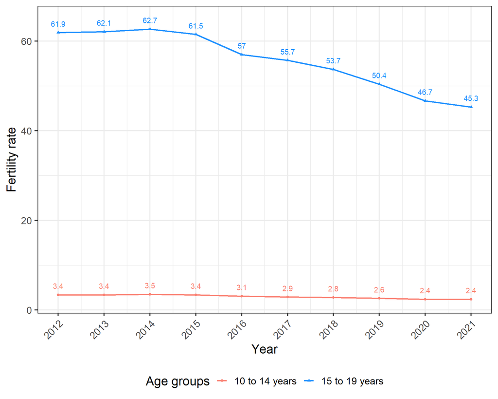

Figure 1: Evolution of fertility rates in the age groups of 10 to 14 years and 15 to 19 years in Brazil, 2012 – 2021.

```r
## Ploting the time series
ggplot(data = df_fecundidade_br_unico, mapping = aes(x = ano, y = tx_fecundidade, color = faixa_etaria)) +
  geom_line(linewidth = 1) +
  geom_point(aes(shape = faixa_etaria)) +
  scale_x_continuous(breaks = unique(df_fecundidade_br_unico$ano), guide = guide_axis(angle = 45)) +
  theme_bw(base_size = 18) +
  labs(
    color = "Age groups",
    shape = "Age groups",
    x = "Year",
    y = "Fertility rate"
  ) +
  geom_text(label = df_fecundidade_br_unico$tx_fecundidade, nudge_y = 2, show.legend = FALSE) +
  theme(legend.position = "bottom") +
  scale_color_manual(values = c("Salmon", "DodgerBlue"))
```

Furthermore, in the period from 2012 to 2021, fertility rates for girls aged 10 to 14 and 15 to 19 years old showed statistically significant decreases in Brazil, going from 3.4 to 2.4 and from 61.9 to 45.3 per 1,000, respectively. The reduction in these rates was also observed in most Federative Units, except in the age group of 10 to 14 years in the Federative Units of Acre, Piauí and Roraima, where they showed non-significant decreasing trends, and in the age group of 15 to 19 years in the Federative Unit of Roraima, where it showed a non-significant decreasing trend (decrease from 94.7 to 92.6, p value = 0.720).

```r
# Mann-Kendall tests for trend analysis
## Joining the country and the states data
df_fecundidade_tendencia <- full_join(
  df_fecundidade_br |> mutate(local = "Brasil", .before = "ano"),
  df_fecundidade_ufs |> rename(local = uf)
)

## Selecting the desired variables
variaveis <- c("tx_fecundidade_10_a_14", "tx_fecundidade_15_a_19")

## Creating a data.frame with the Mann-Kendall tests results
results_table_completa <- data.frame()

for (i in 1:length(unique(df_fecundidade_tendencia$local))) {
  localidade <- unique(df_fecundidade_tendencia$local)[i]

  mann_kendall_results <- lapply(
    df_fecundidade_tendencia |> filter(local == localidade) |> dplyr::select(all_of(variaveis)),
    function(x) {
      mann_kendall_test <- mk.test(x)
      return(c(local = localidade, p_value = mann_kendall_test$p.value, z_value = mann_kendall_test$statistic))
    }
  )

  p_value <- round(as.numeric(unlist(lapply(mann_kendall_results, `[[`, "p_value"))), 5)

  results_table <- data.frame(
    local = as.vector(unlist(lapply(mann_kendall_results, `[[`, "local"))),
    Variavel = names(mann_kendall_results),
    valor_2012 = lapply(
      variaveis,
      function(variavel) df_fecundidade_tendencia |> filter(local == localidade, ano == 2012) |> pull(variavel)
    ) |> as.numeric(),
    valor_2021 = lapply(
      variaveis,
      function(variavel) df_fecundidade_tendencia |> filter(local == localidade, ano == 2021) |> pull(variavel)
    ) |> as.numeric(),
    Mann_Kendall_z = round(as.numeric(unlist(lapply(mann_kendall_results, `[[`, "z_value.z"))), 3),
    Mann_Kendall_p = p_value
  )

  results_table_completa <- bind_rows(results_table_completa, results_table)
}

## Organizing the resulting table
results_table_completa_organizada <- results_table_completa |>
  filter(startsWith(Variavel, "tx")) |>
  pivot_wider(
    names_from = Variavel,
    values_from = c(
      valor_2012,
      valor_2021, Mann_Kendall_z, Mann_Kendall_p
    )
  ) |>
  select_at(vars("local", ends_with("10_a_14"), ends_with("15_a_19")))

## Printing the table
results_table_completa_organizada |>
  kable(
    format = "html",
    col.names = c(
      "",
      "FR 2012", "FR 2021", "Mann-Kendall", "p-value",
      "FR 2012", "FR 2021", "Mann-Kendall", "p-value"
    ),
    align = "lcccccccc",
    caption = "Test statistics and p-value of the Mann-Kendall test for the fertility rate of the age groups 10 to 14 years and 15 to 19 years. Brazil and Federative Units, 2012 - 2021."
  ) |>
  add_header_above(c(
    "Location/age" = 1,
    "10–14 years old" = 4,
    "15–19 years old" = 4
  )) |>
  kable_styling(full_width = FALSE, position = "center")
```

Table 2: Test statistics and p-value of the Mann-Kendall test for the fertility rate of the age groups 10 to 14 years and 15 to 19 years. Brazil and Federative Units, 2012 - 2021.

| Location/age | 10–14 years old FR 2012 | 10–14 years old FR 2021 | 10–14 years old Mann-Kendall | 10–14 years old p-value | 15–19 years old FR 2012 | 15–19 years old FR 2021 | 15–19 years old Mann-Kendall | 15–19 years old p-value |
| --- | --- | --- | --- | --- | --- | --- | --- | --- |
| Brasil | 3.4 | 2.4 | -3.282 | 0.00103 | 61.9 | 45.3 | -3.399 | 0.00068 |
| Acre | 7.1 | 6.4 | -1.443 | 0.14911 | 101.3 | 79.4 | -3.143 | 0.00167 |
| Amapá | 5.8 | 5.1 | -2.525 | 0.01158 | 94.9 | 78.5 | -3.041 | 0.00236 |
| Amazonas | 7.2 | 6.2 | -3.066 | 0.00217 | 101.9 | 88.1 | -3.041 | 0.00236 |
| Pará | 5.7 | 4.9 | -2.735 | 0.00624 | 88.9 | 73.0 | -3.323 | 0.00089 |
| Rondônia | 3.6 | 2.7 | -2.326 | 0.02004 | 73.6 | 54.6 | -3.757 | 0.00017 |
| Roraima | 8.3 | 7.1 | -1.803 | 0.07133 | 94.7 | 92.6 | -0.358 | 0.72051 |
| Tocantins | 5.3 | 4.3 | -2.451 | 0.01424 | 79.8 | 65.0 | -3.220 | 0.00128 |
| Alagoas | 6.1 | 4.3 | -3.607 | 0.00031 | 81.5 | 68.5 | -2.784 | 0.00537 |
| Bahia | 4.0 | 3.0 | -3.387 | 0.00071 | 65.4 | 48.3 | -3.935 | 0.00008 |
| Ceará | 3.9 | 3.0 | -2.735 | 0.00624 | 59.7 | 45.2 | -3.220 | 0.00128 |
| Maranhão | 5.3 | 4.7 | -2.917 | 0.00353 | 84.0 | 70.2 | -2.504 | 0.01227 |
| Paraíba | 3.7 | 2.6 | -2.705 | 0.00683 | 64.8 | 53.4 | -3.041 | 0.00236 |
| Pernambuco | 4.3 | 2.9 | -3.323 | 0.00089 | 71.5 | 52.4 | -3.578 | 0.00035 |
| Piauí | 3.7 | 3.2 | -1.823 | 0.06827 | 67.8 | 55.2 | -2.504 | 0.01227 |
| Rio Grande do Norte | 4.0 | 2.6 | -3.143 | 0.00167 | 62.5 | 44.9 | -3.578 | 0.00035 |
| Sergipe | 4.1 | 3.3 | -2.525 | 0.01158 | 67.7 | 52.1 | -2.862 | 0.00421 |
| Distrito Federal | 2.1 | 1.1 | -3.099 | 0.00194 | 49.0 | 29.5 | -3.757 | 0.00017 |
| Goiás | 3.1 | 1.9 | -3.426 | 0.00061 | 59.9 | 43.3 | -3.220 | 0.00128 |
| Mato Grosso | 4.1 | 3.7 | -2.735 | 0.00624 | 73.8 | 61.6 | -2.963 | 0.00304 |
| Mato Grosso do Sul | 5.0 | 3.2 | -3.399 | 0.00068 | 78.1 | 55.9 | -3.399 | 0.00068 |
| Espírito Santo | 2.8 | 2.3 | -2.425 | 0.01532 | 57.7 | 43.2 | -3.220 | 0.00128 |
| Minas Gerais | 2.0 | 1.4 | -3.099 | 0.00194 | 48.2 | 34.9 | -3.399 | 0.00068 |
| Rio de Janeiro | 2.9 | 1.9 | -3.041 | 0.00236 | 56.6 | 40.3 | -2.963 | 0.00304 |
| São Paulo | 2.2 | 1.1 | -3.502 | 0.00046 | 51.7 | 30.8 | -3.722 | 0.00020 |
| Paraná | 3.0 | 1.6 | -3.426 | 0.00061 | 59.1 | 36.9 | -3.578 | 0.00035 |
| Rio Grande do Sul | 2.2 | 1.3 | -3.066 | 0.00217 | 50.2 | 31.2 | -3.502 | 0.00046 |
| Santa Catarina | 2.2 | 1.1 | -3.350 | 0.00081 | 48.2 | 35.0 | -2.963 | 0.00304 |

# Phase 2: Cluster analysis

This stage of the analysis aimed to find four different groupings for Brazilian municipalities: one that took into account the fertility rate of women aged 10 to 14 in the period from 2018 to 2019; one that took into account this same rate, but in the period from 2020 to 2021; one that took into account the fertility rate of women aged 15 to 19 in the period from 2018 to 2019; and one that considered this same rate, but in the period from 2020 to 2021. To this end, we adjusted non-hierarchical methods (K-means and K-medoids) and hierarchical methods (Ward, single linkage, complete linkage and average linkage). For the non-hierarchical methods, we chose candidates for the number of groups using the knee plot. For the hierarchical methods, we chose candidates for the number of groups using dendrograms. We compared the chosen candidates using the Davies-Bouldin, Dunn, Silhouette and Calinski-Harabasz indices, and chose as final clusters those that presented the best average performance in these metrics (as long as the number of observations in each cluster is adequate). Finally, after determining the four different groupings, we compared, for each grouping, the behavior of some variables of interest in each cluster formed.

```r
# Preparing the data
## Filtering and calculating the fertility rates for each period
df_indicadores_18_19 <- df_indicadores |>
  filter(ano %in% c(2018, 2019)) |>
  group_by(codmunres) |>
  summarise(
    tx_fecundidade_10_a_14 = round(sum(nvm_10_a_14) / sum(pop_feminina_10_a_14) * 1000, 1),
    tx_fecundidade_15_a_19 = round(sum(nvm_15_a_19) / sum(pop_feminina_15_a_19) * 1000, 1),
    cobertura_ab = round(sum(media_cobertura_ab) / sum(populacao_total) * 100, 1),
    porc_exclusivas_sus = round(sum(pop_fem_10_49_com_plano_saude) / sum(pop_feminina_10_a_49) * 100, 1),
    idhm = mean(idhm)
  ) |>
  ungroup()

df_indicadores_20_21 <- df_indicadores |>
  filter(ano %in% c(2020, 2021)) |>
  group_by(codmunres) |>
  summarise(
    tx_fecundidade_10_a_14 = round(sum(nvm_10_a_14) / sum(pop_feminina_10_a_14) * 1000, 1),
    tx_fecundidade_15_a_19 = round(sum(nvm_15_a_19) / sum(pop_feminina_15_a_19) * 1000, 1),
    cobertura_ab = round(sum(media_cobertura_ab) / sum(populacao_total) * 100, 1),
    porc_exclusivas_sus = round(sum(pop_fem_10_49_com_plano_saude) / sum(pop_feminina_10_a_49) * 100, 1),
    idhm = mean(idhm)
  ) |>
  ungroup()

## Standardizing the data for each of the four cluster analysis
dados1_18_19 <- df_indicadores_18_19 |> select(tx_fecundidade_10_a_14) |> scale()
dados2_18_19 <- df_indicadores_18_19 |> select(tx_fecundidade_15_a_19) |> scale()

dados1_20_21 <- df_indicadores_20_21 |> select(tx_fecundidade_10_a_14) |> scale()
dados2_20_21 <- df_indicadores_20_21 |> select(tx_fecundidade_15_a_19) |> scale()

## Calculating the distance matrices
dados1_18_19_dist <- dist(dados1_18_19, method = "euclidean")
dados2_18_19_dist <- dist(dados2_18_19, method = "euclidean")

dados1_20_21_dist <- dist(dados1_20_21, method = "euclidean")
dados2_20_21_dist <- dist(dados2_20_21, method = "euclidean")
```

## For the 10 to 14 age group

### K-Means

#### 2018-2019

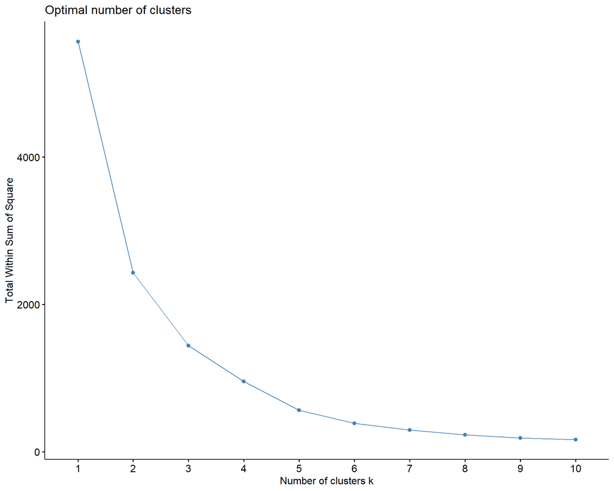

Figure 2: K-Means knee-plot for the 10 to 14 age group and 2018-2019 period

```r
# Ploting the k-means knee-plot for the 2018-2019 period
fviz_nbclust(dados1_18_19, kmeans, method = "wss")
```

- **Candidates:** K = 3 and K = 4 (an argument that the total within-group variance does not decrease significantly after these values can be made for both numbers of groups).

```r
# Adjusting the k-means method with the chosen numbers of clusters
set.seed(1504)
d1_kmeans3_18_19 <- kmeans(dados1_18_19, 3)

set.seed(1504)
d1_kmeans4_18_19 <- kmeans(dados1_18_19, 4)
```

#### 2020-2021

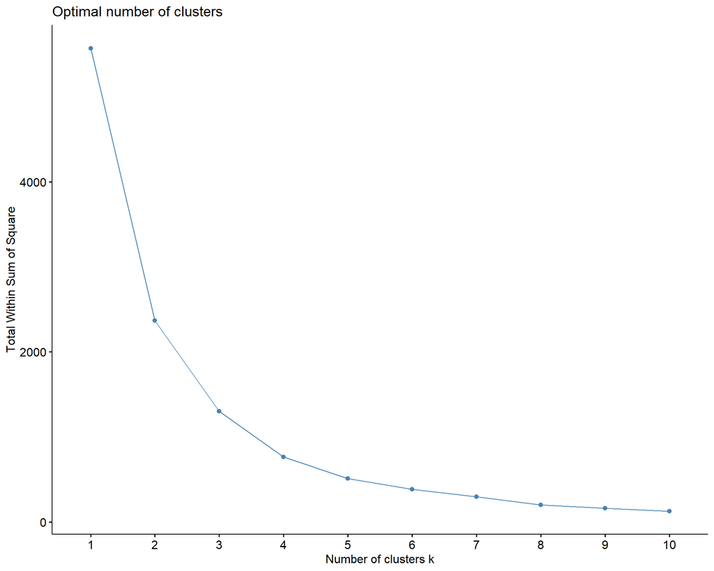

Figure 3: K-Means knee-plot for the 10 to 14 age group and 2020-2021 period

```r
# Ploting the k-means knee-plot for the 2020-2021 period
fviz_nbclust(dados1_20_21, kmeans, method = "wss")
```

- **Candidates:** K = 3 and K = 4 (an argument that the total within-group variance does not decrease significantly after these values can be made for both numbers of groups).

```r
# Adjusting the k-means method with the chosen numbers of clusters
set.seed(1504)
d1_kmeans3_20_21 <- kmeans(dados1_20_21, 3)

set.seed(1504)
d1_kmeans4_20_21 <- kmeans(dados1_20_21, 4)
```

### K-Medians

#### 2018-2019

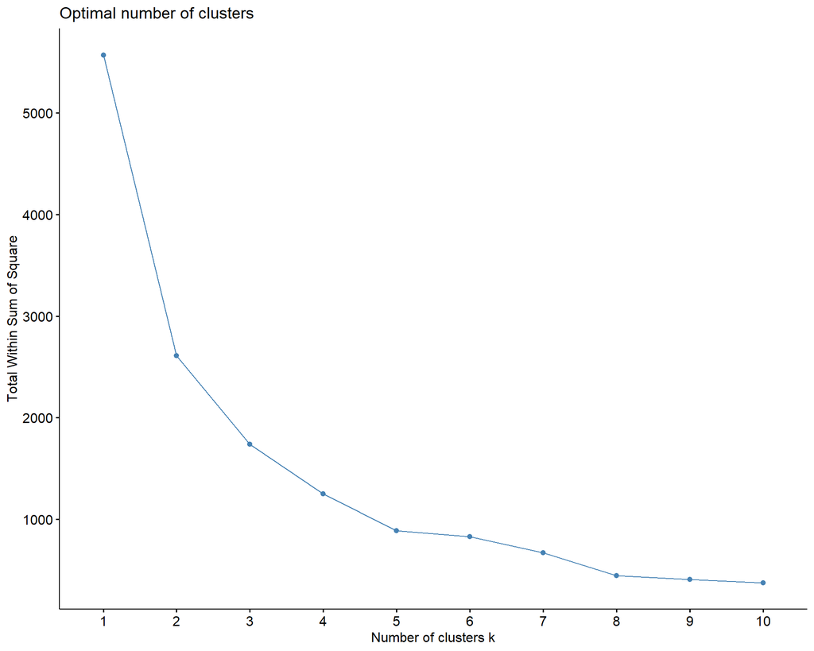

Figure 4: K-Medians knee-plot for the 10 to 14 age group and 2018-2019 period

```r
# Ploting the k-medians knee-plots for the 2018-2019 period
fviz_nbclust(dados1_18_19, cluster::pam, method = "wss")
```

- **Candidates:** K = 3 and K = 4 (an argument that the total within-group variance does not decrease significantly after these values can be made for both numbers of groups).

```r
# Adjusting the k-medians method with the chosen numbers of clusters
set.seed(1504)
d1_pam3_18_19 <- cluster::pam(dados1_18_19, k = 3)

set.seed(1504)
d1_pam4_18_19 <- cluster::pam(dados1_18_19, k = 4)
```

#### 2020-2021

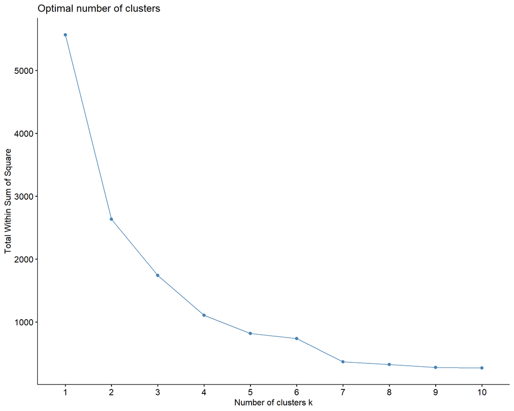

Figure 5: K-Medians knee-plot for the 10 to 14 age group and 2020-2021 period

```r
# Ploting the k-medians knee-plots for the 2020-2021 period
fviz_nbclust(dados1_20_21, cluster::pam, method = "wss")
```

- **Candidates:** K = 3 and K = 4 (an argument that the total within-group variance does not decrease significantly after these values can be made for both numbers of groups).

```r
# Adjusting the k-medians method with the chosen numbers of clusters
set.seed(1504)
d1_pam3_20_21 <- cluster::pam(dados1_20_21, k = 3)

set.seed(1504)
d1_pam4_20_21 <- cluster::pam(dados1_20_21, k = 4)
```

### Ward’s method

#### 2018-2019

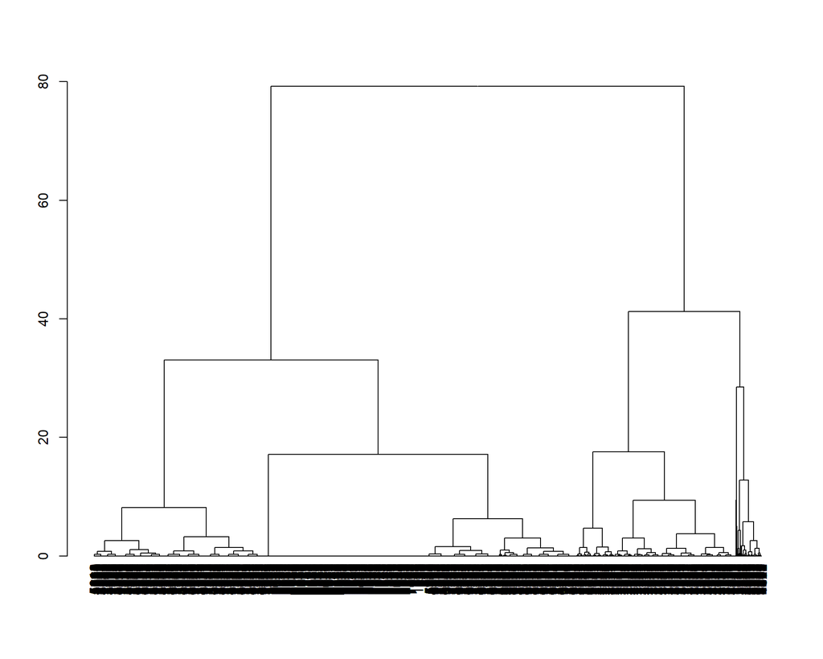

Figure 6: Dendrogram for Ward’s method for the 10 to 14 age group and 2018-2019 period

```r
# Ploting the drodrogram for the 2018-2019 period
set.seed(1504)
d1_ward_18_19 <- hclust(dados1_18_19_dist, method = "ward.D2")
plot(as.dendrogram(d1_ward_18_19))
```

- **Candidates:** K = 2 and K = 3.

```r
# Adjusting the Ward's method with the chosen numbers of clusters
d1_ward2_18_19_class <- cutree(d1_ward_18_19, k = 2)
d1_ward3_18_19_class <- cutree(d1_ward_18_19, k = 3)
```

#### 2020-2021

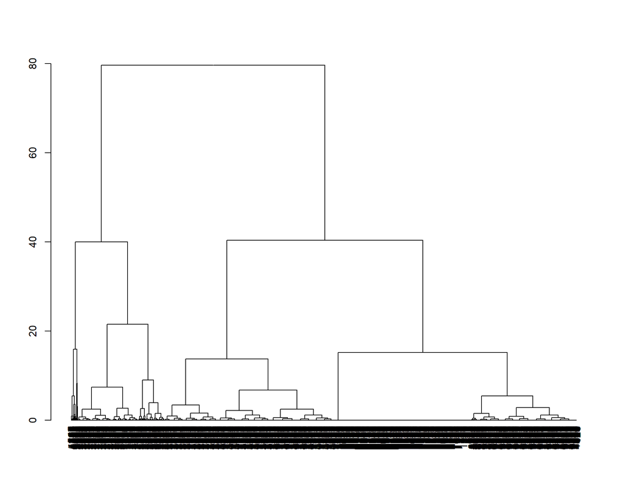

Figure 7: Dendrogram for Ward’s method for the 10 to 14 age group and 2020-2021 period

```r
# Ploting the drodrogram for the 2020-2021 period
set.seed(1504)
d1_ward_20_21 <- hclust(dados1_20_21_dist, method = "ward.D2")
plot(as.dendrogram(d1_ward_20_21))
```

- **Candidates:** K = 2 and K = 4.

```r
d1_ward2_20_21_class <- cutree(d1_ward_20_21, k = 2)
d1_ward4_20_21_class <- cutree(d1_ward_20_21, k = 4)
```

### Single linkage

#### 2018-2019

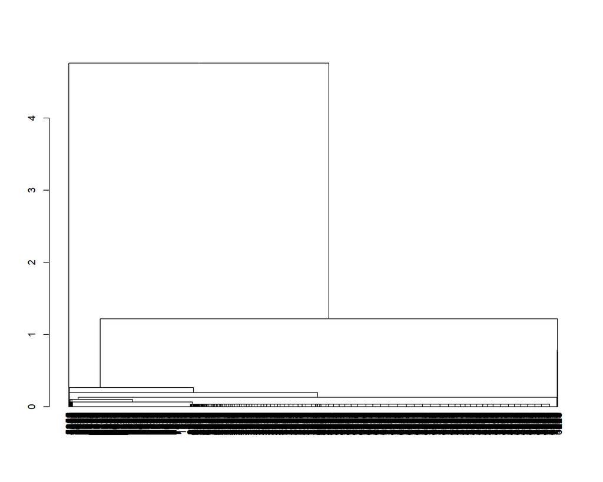

Figure 8: Dendrogram for the single linkage method for the 10 to 14 age group and 2018-2019 period

```r
### Single linkage
#### Ploting the dendrograms
set.seed(1504)
d1_single_18_19 <- hclust(dados1_18_19_dist, method = "single")
plot(as.dendrogram(d1_single_18_19))
```

- **Candidates:** No candidates. A bad fit overall.

#### 2020-2021

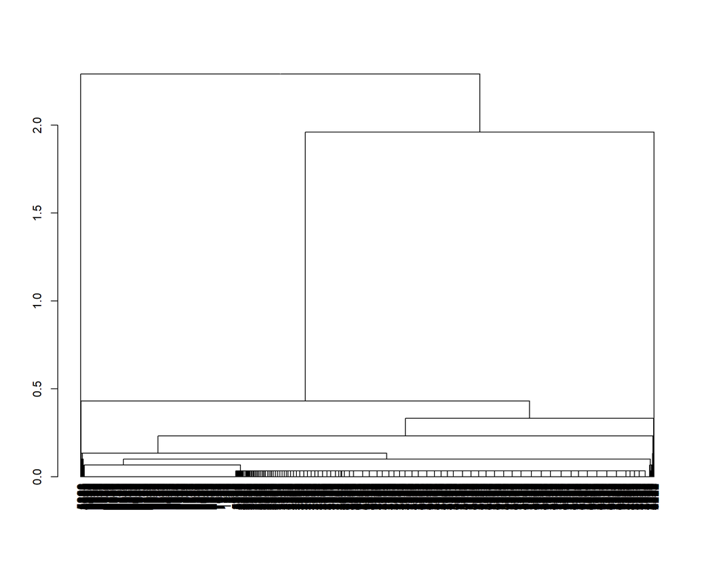

Figure 9: Dendrogram for the single linkage method for the 10 to 14 age group and 2020-2021 period

```r
set.seed(1504)
d1_single_20_21 <- hclust(dados1_20_21_dist, method = "single")
plot(as.dendrogram(d1_single_20_21))
```

- **Candidates:** No candidates. A bad fit overall.

### Complete linkage

#### 2018-2019

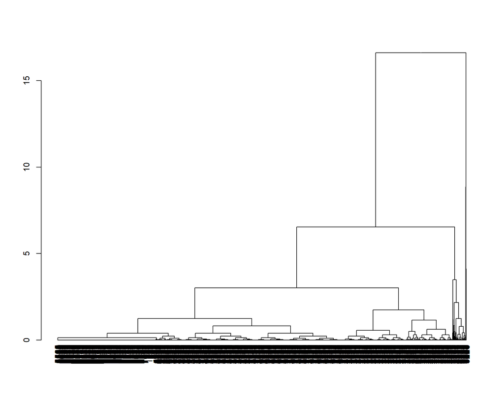

Figure 10: Dendrogram for the complete linkage method for the 10 to 14 age group and 2018-2019 period

```r
### Complete linkage
#### Ploting the dendrograms
set.seed(1504)
d1_complete_18_19 <- hclust(dados1_18_19_dist, method = "complete")
plot(as.dendrogram(d1_complete_18_19))
```

- **Candidates:** No candidates. A bad fit overall.

#### 2020-2021

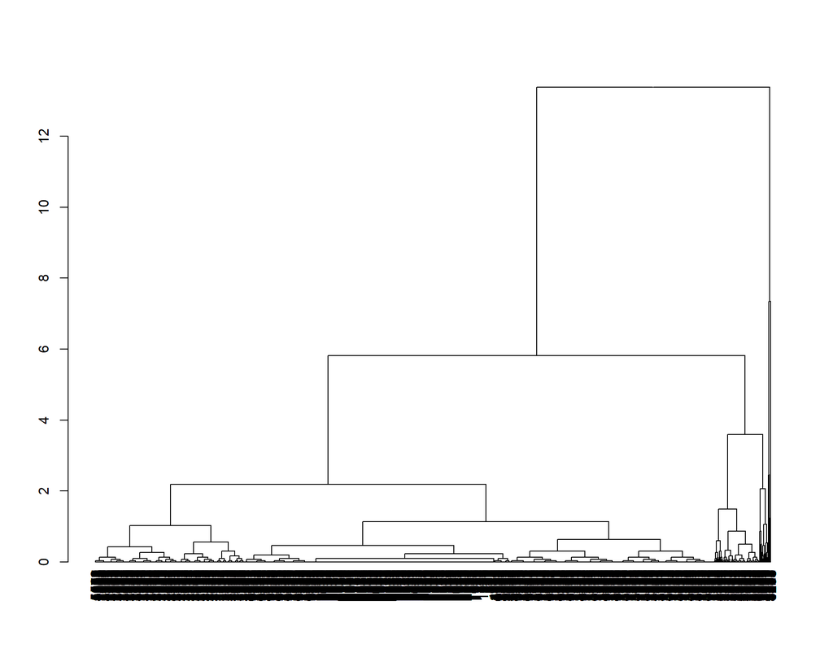

Figure 11: Dendrogram for the complete linkage method for the 10 to 14 age group and 2020-2021 period

```r
set.seed(1504)
d1_complete_20_21 <- hclust(dados1_20_21_dist, method = "complete")
plot(as.dendrogram(d1_complete_20_21))
```

- **Candidates:** No candidates. A bad fit overall.

### Average linkage

#### 2018-2019

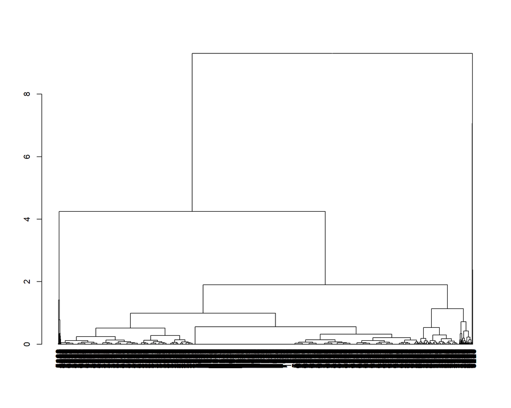

Figure 12: Dendrogram for the average linkage method for the 10 to 14 age group and 2018-2019 period

```r
### Average linkage
#### Ploting the dendrograms
set.seed(1504)
d1_average_18_19 <- hclust(dados1_18_19_dist, method = "average")
plot(as.dendrogram(d1_average_18_19))
```

- **Candidates:** No candidates. A bad fit overall.

#### 2020-2021

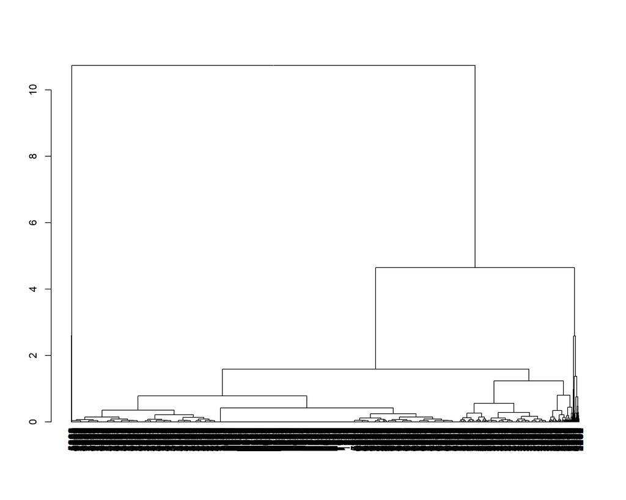

Figure 13: Dendrogram for the average linkage method for the 10 to 14 age group and 2020-2021 period

```r
set.seed(1504)
d1_average_20_21 <- hclust(dados1_20_21_dist, method = "average")
plot(as.dendrogram(d1_average_20_21))
```

- **Candidates:** No candidates. A bad fit overall.

### Choosing the best clustering method

#### 2018-2019

```r
## Calculating the considered indices
d1_kmeans_index_18_19 <- data.frame(
  method = unlist(lapply(3:4, function(i) paste0("kmeans", i))),
  db_index_cent = unlist(lapply(3:4, function(i) index.DB(dados1_18_19, get(paste0("d1_kmeans", i, "_18_19"))$cluster)$DB)),
  db_index_med = unlist(lapply(3:4, function(i) index.DB(dados1_18_19, get(paste0("d1_kmeans", i, "_18_19"))$cluster, d = dados1_18_19_dist, centrotypes = "medoids")$DB)),
  dunn_index = unlist(lapply(3:4, function(i) dunn(distance = dados1_18_19_dist, get(paste0("d1_kmeans", i, "_18_19"))$cluster))),
  silh_index = unlist(lapply(3:4, function(i) index.S(dados1_18_19_dist, get(paste0("d1_kmeans", i, "_18_19"))$cluster))),
  ch_index_cent = unlist(lapply(3:4, function(i) index.G1(dados1_18_19, get(paste0("d1_kmeans", i, "_18_19"))$cluster))),
  ch_index_med = unlist(lapply(3:4, function(i) index.G1(dados1_18_19, get(paste0("d1_kmeans", i, "_18_19"))$cluster, d = dados1_18_19_dist, centrotypes = "medoids")))
)

d1_pam_index_18_19 <- data.frame(
  method = unlist(lapply(3:4, function(i) paste0("pam", i))),
  db_index_cent = unlist(lapply(3:4, function(i) index.DB(dados1_18_19, get(paste0("d1_pam", i, "_18_19"))$cluster)$DB)),
  db_index_med = unlist(lapply(3:4, function(i) index.DB(dados1_18_19, get(paste0("d1_pam", i, "_18_19"))$cluster, d = dados1_18_19_dist, centrotypes = "medoids")$DB)),
  dunn_index = unlist(lapply(3:4, function(i) dunn(distance = dados1_18_19_dist, get(paste0("d1_pam", i, "_18_19"))$cluster))),
  silh_index = unlist(lapply(3:4, function(i) index.S(dados1_18_19_dist, get(paste0("d1_pam", i, "_18_19"))$cluster))),
  ch_index_cent = unlist(lapply(3:4, function(i) index.G1(dados1_18_19, get(paste0("d1_pam", i, "_18_19"))$cluster))),
  ch_index_med = unlist(lapply(3:4, function(i) index.G1(dados1_18_19, get(paste0("d1_pam", i, "_18_19"))$cluster, d = dados1_18_19_dist, centrotypes = "medoids")))
)

d1_ward_index_18_19 <- data.frame(
  method = unlist(lapply(2:3, function(i) paste0("ward", i))),
  db_index_cent = unlist(lapply(2:3, function(i) index.DB(dados1_18_19, get(paste0("d1_ward", i, "_18_19", "_class")))$DB)),
  db_index_med = unlist(lapply(2:3, function(i) index.DB(dados1_18_19, get(paste0("d1_ward", i, "_18_19", "_class")), d = dados1_18_19_dist, centrotypes = "medoids")$DB)),
  dunn_index = unlist(lapply(2:3, function(i) dunn(distance = dados1_18_19_dist, get(paste0("d1_ward", i, "_18_19", "_class"))))),
  silh_index = unlist(lapply(2:3, function(i) index.S(dados1_18_19_dist, get(paste0("d1_ward", i, "_18_19", "_class"))))),
  ch_index_cent = unlist(lapply(2:3, function(i) index.G1(dados1_18_19, get(paste0("d1_ward", i, "_18_19", "_class"))))),
  ch_index_med = unlist(lapply(2:3, function(i) index.G1(dados1_18_19, get(paste0("d1_ward", i, "_18_19", "_class")), d = dados1_18_19_dist, centrotypes = "medoids")))
)

## Printing the table
d1_avaliacao_18_19 <- rbind(
  d1_pam_index_18_19,
  d1_kmeans_index_18_19,
  d1_ward_index_18_19
)
d1_avaliacao_18_19 |> kable()
```

| method | db_index_cent | db_index_med | dunn_index | silh_index | ch_index_cent | ch_index_med |
| --- | --- | --- | --- | --- | --- | --- |
| pam3 | 0.8198007 | 1.010448 | 0.0021692 | 0.5658505 | 6140.890 | 5859.125 |
| pam4 | 0.8037138 | 1.063107 | 0.0022371 | 0.5885946 | 6398.828 | 6004.266 |
| kmeans3 | 0.8336077 | 1.002882 | 0.0023148 | 0.5800877 | 7973.284 | 7776.422 |
| kmeans4 | 0.7828237 | 1.013612 | 0.0024876 | 0.5864388 | 9010.328 | 8048.691 |
| ward2 | 0.8790065 | 1.096638 | 0.0021505 | 0.6092797 | 7193.089 | 6985.303 |
| ward3 | 0.8480933 | 1.060615 | 0.0023981 | 0.5786352 | 7022.586 | 6973.459 |

**Comments:**

- db_index_cent: the lower the better (kmeans4, followed by pam4);
- db_index_med: the lower the better (kmeans3, followed by pam3 and kmeans4);
- dunn_index: the higher the better (kmeans4, followed by ward3 and kmeans3);
- silh_index: the higher the better (ward2, followed by pam4, kmeans4 and kmeans3);
- ch_index_cent: the higher the better (kmeans4, followed by kmeans3);
- ch_index_med: the higher the better (kmeans4, followed by kmeans3).

**Choice:** despite the better perfomance of k-means with K = 4, one of its clusters contained only a few municipalities (127).

```r
d1_kmeans4_18_19$size
```

```
## [1]  998 2176  127 2269
```

```r
d1_kmeans3_18_19$size
```

```
## [1] 2162 3012  396
```

Thus, the chosen method is the **k-means with K = 3**, since it presented the best Davies-Bouldin (medoid) index, the second best Calinski-Harabasz indexes and good Dunn and Silhouette indexes.

```r
# Adding the column with the clusters information to the original dataframe
df_indicadores_18_19$cluster_10_a_14 <- d1_kmeans3_18_19$cluster

# Ordering by mean fertility rate
ordem_taxa1_18_19 <- df_indicadores_18_19 |>
  group_by(cluster_10_a_14) |>
  summarise(tx_fecundidade_10_a_14 = mean(tx_fecundidade_10_a_14)) |>
  ungroup() |>
  arrange(tx_fecundidade_10_a_14) |>
  pull(cluster_10_a_14)

df_indicadores_18_19$cluster_10_a_14 <- factor(case_when(
  df_indicadores_18_19$cluster_10_a_14 == ordem_taxa1_18_19[1] ~ "1: lowest fertility rates",
  df_indicadores_18_19$cluster_10_a_14 == ordem_taxa1_18_19[2] ~ "2: intermediary fertility rates",
  df_indicadores_18_19$cluster_10_a_14 == ordem_taxa1_18_19[3] ~ "3: highest fertility rates"
))
```

#### 2020-2021

```r
# Calculating the considered indices
d1_kmeans_index_20_21 <- data.frame(
  metodo = unlist(lapply(3:4, function(i) paste0("kmeans", i))),
  db_index_cent = unlist(lapply(3:4, function(i) index.DB(dados1_20_21, get(paste0("d1_kmeans", i, "_20_21"))$cluster)$DB)),
  db_index_med = unlist(lapply(3:4, function(i) index.DB(dados1_20_21, get(paste0("d1_kmeans", i, "_20_21"))$cluster, d = dados1_20_21_dist, centrotypes = "medoids")$DB)),
  dunn_index = unlist(lapply(3:4, function(i) dunn(distance = dados1_20_21_dist, get(paste0("d1_kmeans", i, "_20_21"))$cluster))),
  silh_index = unlist(lapply(3:4, function(i) index.S(dados1_20_21_dist, get(paste0("d1_kmeans", i, "_20_21"))$cluster))),
  ch_index_cent = unlist(lapply(3:4, function(i) index.G1(dados1_20_21, get(paste0("d1_kmeans", i, "_20_21"))$cluster))),
  ch_index_med = unlist(lapply(3:4, function(i) index.G1(dados1_20_21, get(paste0("d1_kmeans", i, "_20_21"))$cluster, d = dados1_20_21_dist, centrotypes = "medoids")))
)

d1_pam_index_20_21 <- data.frame(
  metodo = unlist(lapply(3:4, function(i) paste0("pam", i))),
  db_index_cent = unlist(lapply(3:4, function(i) index.DB(dados1_20_21, get(paste0("d1_pam", i, "_20_21"))$cluster)$DB)),
  db_index_med = unlist(lapply(3:4, function(i) index.DB(dados1_20_21, get(paste0("d1_pam", i, "_20_21"))$cluster, d = dados1_20_21_dist, centrotypes = "medoids")$DB)),
  dunn_index = unlist(lapply(3:4, function(i) dunn(distance = dados1_20_21_dist, get(paste0("d1_pam", i, "_20_21"))$cluster))),
  silh_index = unlist(lapply(3:4, function(i) index.S(dados1_20_21_dist, get(paste0("d1_pam", i, "_20_21"))$cluster))),
  ch_index_cent = unlist(lapply(3:4, function(i) index.G1(dados1_20_21, get(paste0("d1_pam", i, "_20_21"))$cluster))),
  ch_index_med = unlist(lapply(3:4, function(i) index.G1(dados1_20_21, get(paste0("d1_pam", i, "_20_21"))$cluster, d = dados1_20_21_dist, centrotypes = "medoids")))
)

d1_ward_index_20_21 <- data.frame(
  metodo = unlist(lapply(c(2, 4), function(i) paste0("ward", i))),
  db_index_cent = unlist(lapply(c(2, 4), function(i) index.DB(dados1_20_21, get(paste0("d1_ward", i, "_20_21", "_class")))$DB)),
  db_index_med = unlist(lapply(c(2, 4), function(i) index.DB(dados1_20_21, get(paste0("d1_ward", i, "_20_21", "_class")), d = dados1_20_21_dist, centrotypes = "medoids")$DB)),
  dunn_index = unlist(lapply(c(2, 4), function(i) dunn(distance = dados1_20_21_dist, get(paste0("d1_ward", i, "_20_21", "_class"))))),
  silh_index = unlist(lapply(c(2, 4), function(i) index.S(dados1_20_21_dist, get(paste0("d1_ward", i, "_20_21", "_class"))))),
  ch_index_cent = unlist(lapply(c(2, 4), function(i) index.G1(dados1_20_21, get(paste0("d1_ward", i, "_20_21", "_class"))))),
  ch_index_med = unlist(lapply(c(2, 4), function(i) index.G1(dados1_20_21, get(paste0("d1_ward", i, "_20_21", "_class")), d = dados1_20_21_dist, centrotypes = "medoids")))
)

# Printing the table
d1_avaliacao_20_21 <- rbind(
  d1_pam_index_20_21,
  d1_kmeans_index_20_21,
  d1_ward_index_20_21
)
d1_avaliacao_20_21
```

```
##    metodo db_index_cent db_index_med  dunn_index silh_index ch_index_cent
## 1    pam3     0.8172548    1.0793661 0.002770083  0.5656204      6121.451
## 2    pam4     0.7682952    1.0212080 0.002932551  0.5952804      7495.894
## 3 kmeans3     0.7644580    0.9449188 0.003076923  0.5973804      9097.737
## 4 kmeans4     0.6547798    0.7422809 0.003472222  0.5978453     11615.918
## 5   ward2     0.8329748    1.0298080 0.002816901  0.6397901      7363.678
## 6   ward4     0.6518735    0.7245958 0.003649635  0.5881173     11320.427
##   ch_index_med
## 1     5684.212
## 2     7063.963
## 3     8762.034
## 4    10492.895
## 5     7155.641
## 6     9823.375
```

**Comments:**

- db_index_cent: the lower the better (ward4, followed by kmeans4 and kmeans3);
- db_index_med: the lower the better (ward4, followed by kmeans4 and kmeans3);
- dunn_index: the higher the better (ward4, followed by kmeans4 and kmeans3);
- silh_index: the higher the better (ward2, followed by kmeans4 and kmeans3);
- ch_index_cent: the higher the better (kmeans4, followed by ward4 and kmeans3);
- ch_index_med: the higher the better (kmeans4, followed by ward4 and kmeans3).

**Choice:** again, despite the better perfomance of k-means with K = 4 and Ward’s method with K = 4, one of their clusters contained only a few municipalities (90 and 70, respectively).

```r
d1_kmeans4_20_21$size
```

```
## [1] 2109 2459   90  912
```

```r
table(d1_ward4_20_21_class)
```

```
## d1_ward4_20_21_class
##    1    2    3    4
## 2627 1909  964   70
```

```r
d1_kmeans3_18_19$size
```

```
## [1] 2162 3012  396
```

Thus, the chosen method is the **K-Means with K = 3**, since it had the best overall performance after these two.

```r
# Adding the column with the clusters information to the original dataframe
df_indicadores_20_21$cluster_10_a_14 <- d1_kmeans3_20_21$cluster

# Ordering by mean fertility rate
ordem_taxa1_20_21 <- df_indicadores_20_21 |>
  group_by(cluster_10_a_14) |>
  summarise(tx_fecundidade_10_a_14 = mean(tx_fecundidade_10_a_14)) |>
  ungroup() |>
  arrange(tx_fecundidade_10_a_14) |>
  pull(cluster_10_a_14)

df_indicadores_20_21$cluster_10_a_14 <- factor(case_when(
  df_indicadores_20_21$cluster_10_a_14 == ordem_taxa1_20_21[1] ~ "1: lowest fertility rates",
  df_indicadores_20_21$cluster_10_a_14 == ordem_taxa1_20_21[2] ~ "2: intermediary fertility rates",
  df_indicadores_20_21$cluster_10_a_14 == ordem_taxa1_20_21[3] ~ "3: highest fertility rates"
))
```

## For the 15 to 19 age group

### K-Means

#### 2018-2019

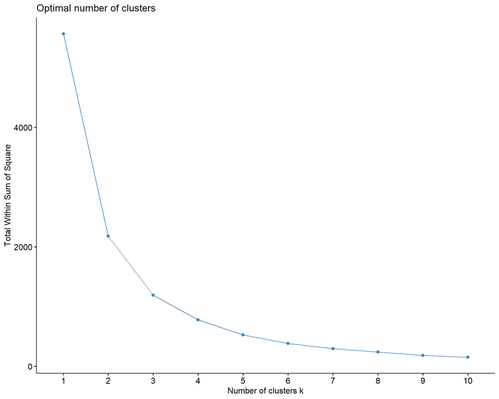

Figure 14: K-Means knee-plot for the 15 to 19 age group and 2018-2019 period

```r
# Ploting the k-means knee-plot for the 2018-2019 period
set.seed(1504)
fviz_nbclust(dados2_18_19, kmeans, method = "wss")
```

- **Candidates:** K = 3 and K = 4 (an argument that the total within-group variance does not decrease significantly after these values can be made for both numbers of groups).

```r
# Adjusting the k-means method with the chosen numbers of clusters
set.seed(1504)
d2_kmeans3_18_19 <- kmeans(dados2_18_19, 3)

set.seed(1504)
d2_kmeans4_18_19 <- kmeans(dados2_18_19, 4)
```

#### 2020-2021

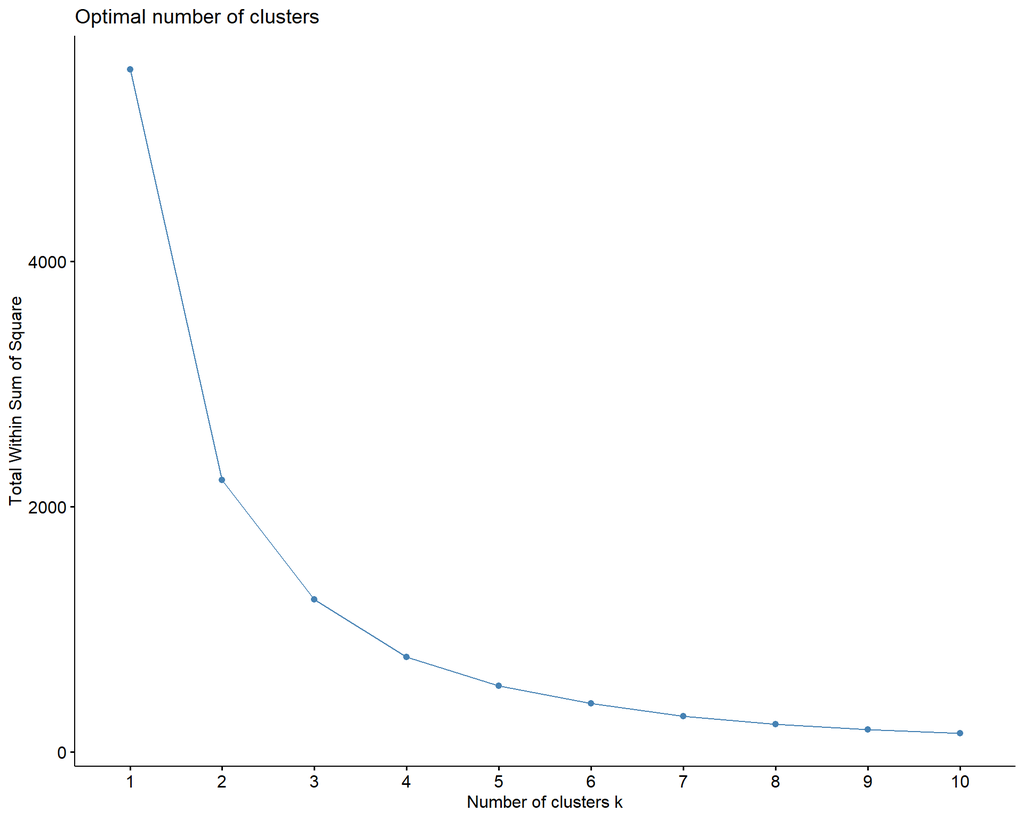

Figure 15: K-Means knee-plot for the 15 to 19 age group and 2020-2021 period

```r
set.seed(1504)
fviz_nbclust(dados2_20_21, kmeans, method = "wss")
```

- **Candidates:** K = 3 and K = 4 (an argument that the total within-group variance does not decrease significantly after these values can be made for both numbers of groups).

```r
# Adjusting the k-means method with the chosen numbers of clusters
set.seed(1504)
d2_kmeans3_20_21 <- kmeans(dados2_20_21, 3)

set.seed(1504)
d2_kmeans4_20_21 <- kmeans(dados2_20_21, 4)
```

### K-Medians

#### 2018-2019

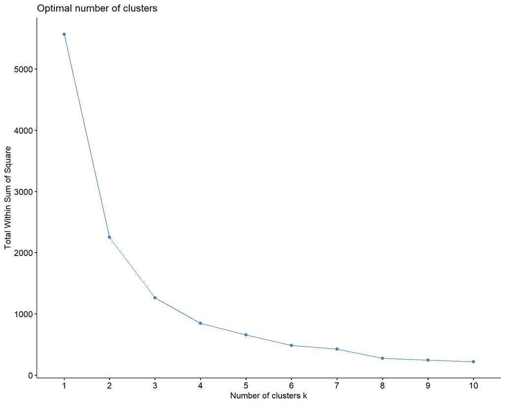

Figure 16: K-Medians knee-plot for the 15 to 19 age group and 2018-2019 period

```r
set.seed(1504)
fviz_nbclust(dados2_18_19, cluster::pam, method = "wss")
```

- **Candidates:** K = 3 (an argument can be made that only after this value the total within-group variance does not decrease significantly).

```r
# Adjusting the k-medians method with the chosen numbers of clusters
set.seed(1504)
d2_pam3_18_19 <- cluster::pam(dados2_18_19, k = 3)
```

#### 2020-2021

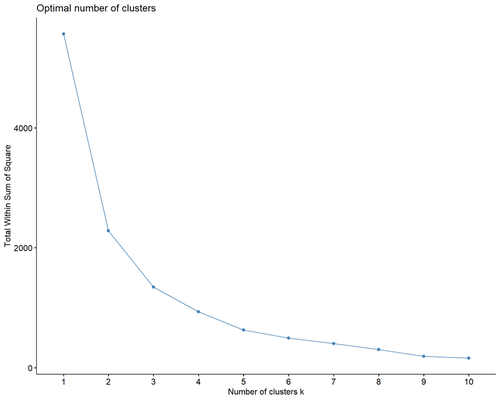

Figure 17: K-Medians knee-plot for the 15 to 19 age group and 2020-2021 period

```r
set.seed(1504)
fviz_nbclust(dados2_20_21, cluster::pam, method = "wss")
```

- **Candidates:** K = 3 and K = 4 (an argument that the total within-group variance does not decrease significantly after these values can be made for both numbers of groups).

```r
# Adjusting the k-medians method with the chosen numbers of clusters
set.seed(1504)
d2_pam3_20_21 <- cluster::pam(dados2_20_21, k = 3)

set.seed(1504)
d2_pam4_20_21 <- cluster::pam(dados2_20_21, k = 4)
```

### Ward’s method

#### 2018-2019

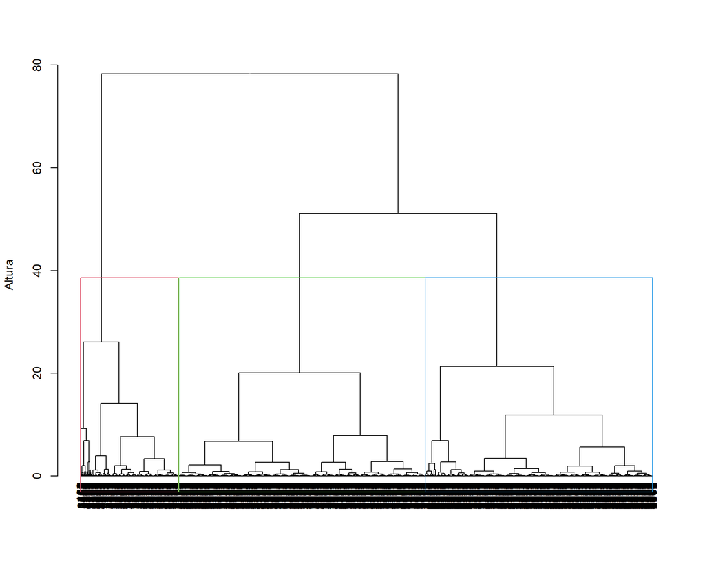

Figure 18: Dendrogram for Ward’s method for the 15 to 19 age group and 2018-2019 period

```r
# Ploting the drodrograms
set.seed(1504)
d2_ward_18_19 <- hclust(dados2_18_19_dist, method = "ward.D2")
plot(as.dendrogram(d2_ward_18_19), ylab = "Altura")
rect.hclust(d2_ward_18_19, k = 3, border = 2:5)
```

- **Candidates:** K = 3.

```r
# Adjusting the Ward's method with the chosen numbers of clusters
d2_ward3_18_19_class <- cutree(d2_ward_18_19, k = 3)
```

#### 2020-2021

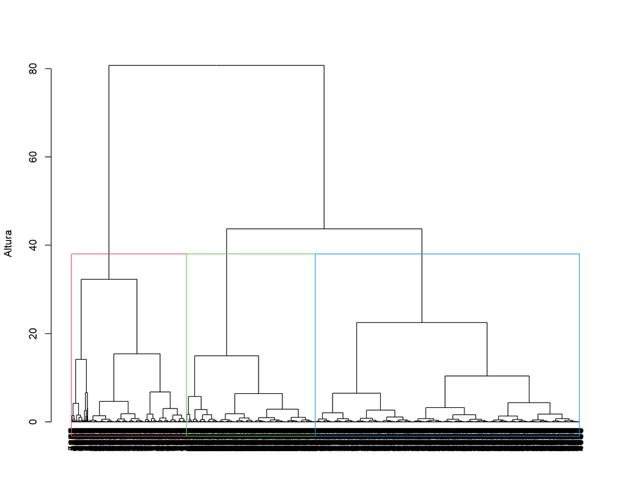

Figure 19: Dendrogram for Ward’s method for the 15 to 19 age group and 2020-2021 period

```r
set.seed(1504)
d2_ward_20_21 <- hclust(dados2_20_21_dist, method = "ward.D2")
plot(as.dendrogram(d2_ward_20_21), ylab = "Altura")
rect.hclust(d2_ward_20_21, k = 3, border = 2:5)
```

- **Candidates:** K = 3.

```r
# Adjusting the Ward's method with the chosen numbers of clusters
d2_ward3_20_21_class <- cutree(d2_ward_20_21, k = 3)
```

### Single linkage

#### 2018-2019

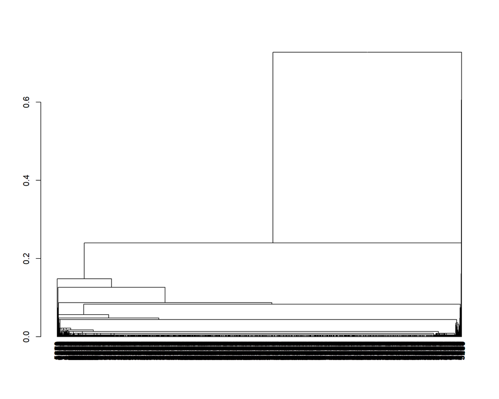

Figure 20: Dendrogram for the single linkage method for the 15 to 19 age group and 2018-2019 period

```r
set.seed(1504)
d2_single_18_19 <- hclust(dados2_18_19_dist, method = "single")
plot(as.dendrogram(d2_single_18_19))
```

- **Candidates:** No candidates. A bad fit overall.

#### 2020-2021

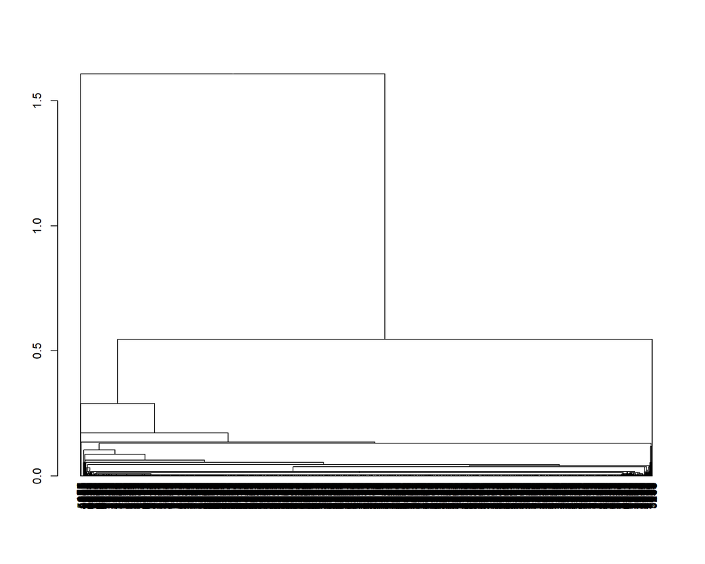

Figure 21: Dendrogram for the single linkage method for the 15 to 19 age group and 2020-2021 period

```r
set.seed(1504)
d2_single_20_21 <- hclust(dados2_20_21_dist, method = "single")
plot(as.dendrogram(d2_single_20_21))
```

- **Candidates:** No candidates. A bad fit overall.

### Complete linkage

#### 2018-2019

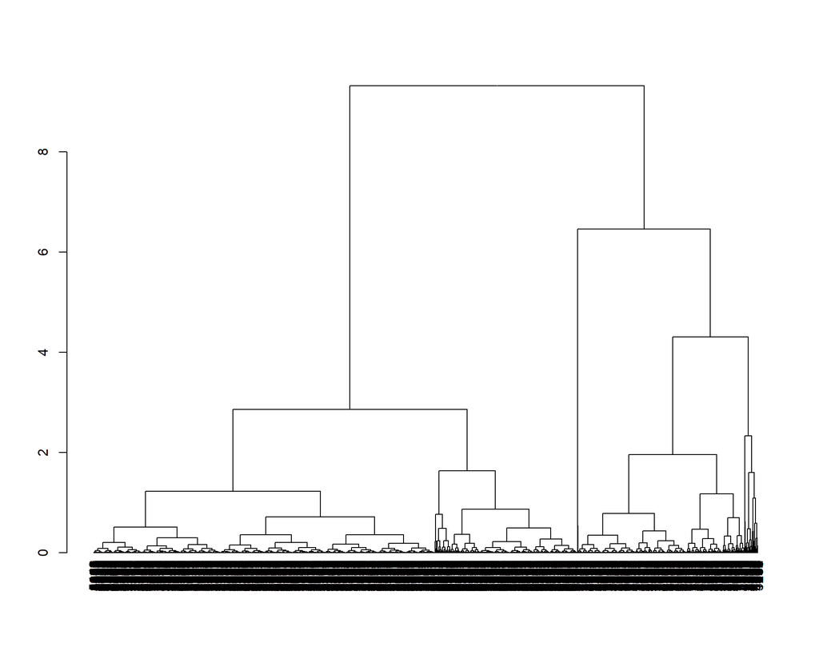

Figure 22: Dendrogram for the complete linkage method for the 15 to 19 age group and 2018-2019 period

```r
set.seed(1504)
d2_complete_18_19 <- hclust(dados2_18_19_dist, method = "complete")
plot(as.dendrogram(d2_complete_18_19))
```

- **Candidates:** No candidates. A bad fit overall.

#### 2020-2021

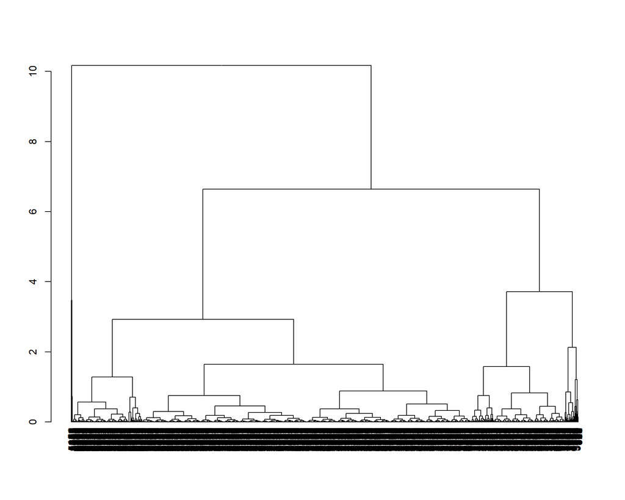

Figure 23: Dendrogram for the complete linkage method for the 15 to 19 age group and 2020-2021 period

```r
set.seed(1504)
d2_complete_20_21 <- hclust(dados2_20_21_dist, method = "complete")
plot(as.dendrogram(d2_complete_20_21))
```

- **Candidates:** No candidates. A bad fit overall.

### Average linkage

#### 2018-2019

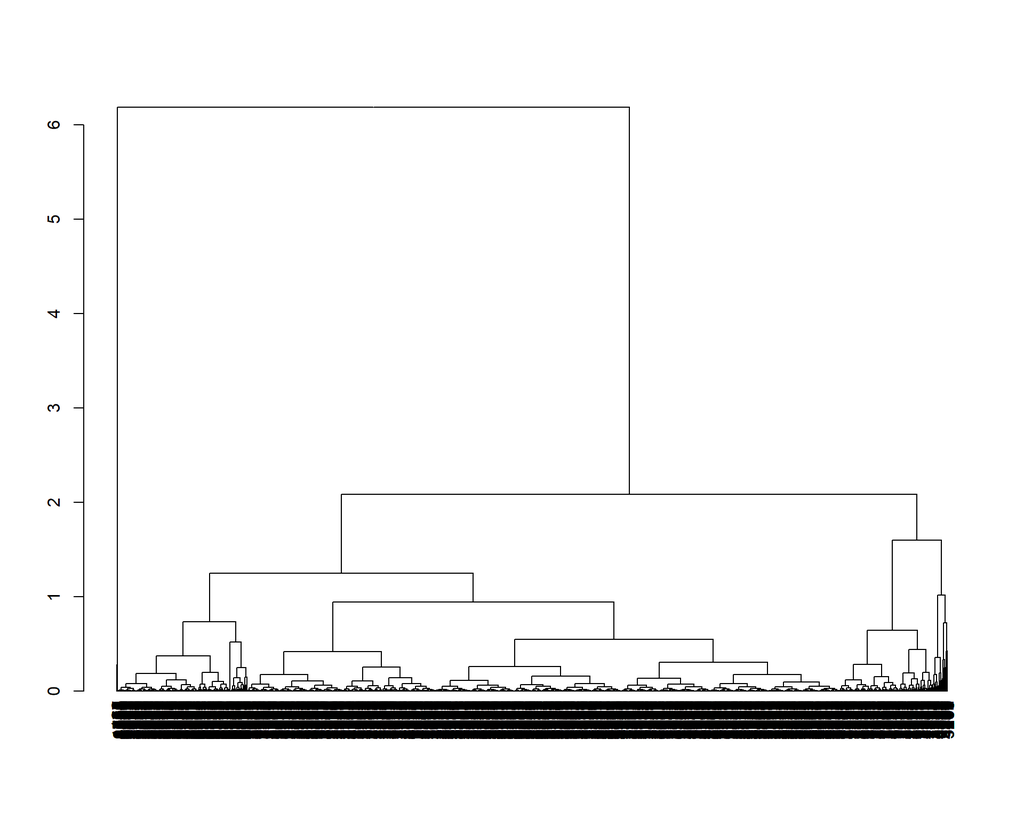

Figure 24: Dendrogram for the average linkage method for the 15 to 19 age group and 2018-2019 period

```r
set.seed(1504)
d2_average_18_19 <- hclust(dados2_18_19_dist, method = "average")
plot(as.dendrogram(d2_average_18_19))
```

- **Candidates:** No candidates. A bad fit overall.

#### 2020-2021

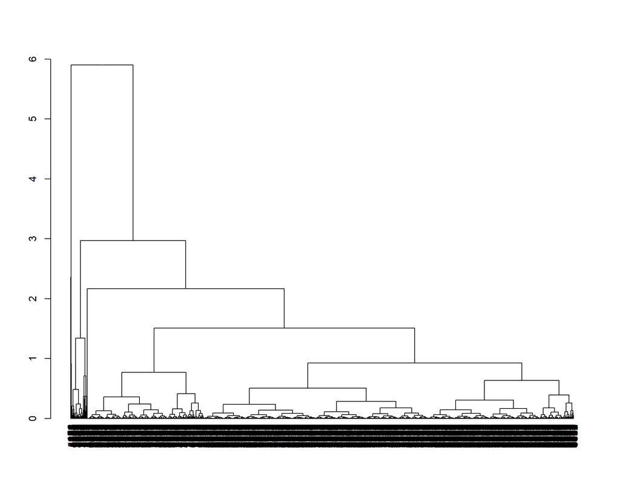

Figure 25: Dendrogram for the average linkage method for the 15 to 19 age group and 2020-2021 period

```r
set.seed(1504)
d2_average_20_21 <- hclust(dados2_20_21_dist, method = "average")
plot(as.dendrogram(d2_average_20_21))
```

- **Candidates:** No candidates. A bad fit overall.

### Choosing the best clustering method

#### 2018-2019

```r
# Calculating the considered indices
d2_kmeans_index_18_19 <- data.frame(
  metodo = unlist(lapply(3:4, function(i) paste0("kmeans", i))),
  db_index_cent = unlist(lapply(3:4, function(i) index.DB(dados2_18_19, get(paste0("d2_kmeans", i, "_18_19"))$cluster)$DB)),
  db_index_med = unlist(lapply(3:4, function(i) index.DB(dados2_18_19, get(paste0("d2_kmeans", i, "_18_19"))$cluster, d = dados2_18_19_dist, centrotypes = "medoids")$DB)),
  dunn_index = unlist(lapply(3:4, function(i) dunn(distance = dados2_18_19_dist, get(paste0("d2_kmeans", i, "_18_19"))$cluster))),
  silh_index = unlist(lapply(3:4, function(i) index.S(dados2_18_19_dist, get(paste0("d2_kmeans", i, "_18_19"))$cluster))),
  ch_index_cent = unlist(lapply(3:4, function(i) index.G1(dados2_18_19, get(paste0("d2_kmeans", i, "_18_19"))$cluster))),
  ch_index_med = unlist(lapply(3:4, function(i) index.G1(dados2_18_19, get(paste0("d2_kmeans", i, "_18_19"))$cluster, d = dados2_18_19_dist, centrotypes = "medoids")))
)

d2_pam_index_18_19 <- data.frame(
  metodo = unlist(lapply(3, function(i) paste0("pam", i))),
  db_index_cent = unlist(lapply(3, function(i) index.DB(dados2_18_19, get(paste0("d2_pam", i, "_18_19"))$cluster)$DB)),
  db_index_med = unlist(lapply(3, function(i) index.DB(dados2_18_19, get(paste0("d2_pam", i, "_18_19"))$cluster, d = dados2_18_19_dist, centrotypes = "medoids")$DB)),
  dunn_index = unlist(lapply(3, function(i) dunn(distance = dados2_18_19_dist, get(paste0("d2_pam", i, "_18_19"))$cluster))),
  silh_index = unlist(lapply(3, function(i) index.S(dados2_18_19_dist, get(paste0("d2_pam", i, "_18_19"))$cluster))),
  ch_index_cent = unlist(lapply(3, function(i) index.G1(dados2_18_19, get(paste0("d2_pam", i, "_18_19"))$cluster))),
  ch_index_med = unlist(lapply(3, function(i) index.G1(dados2_18_19, get(paste0("d2_pam", i, "_18_19"))$cluster, d = dados2_18_19_dist, centrotypes = "medoids")))
)

d2_ward_index_18_19 <- data.frame(
  metodo = unlist(lapply(3, function(i) paste0("ward", i))),
  db_index_cent = unlist(lapply(3, function(i) index.DB(dados2_18_19, get(paste0("d2_ward", i, "_18_19", "_class")))$DB)),
  db_index_med = unlist(lapply(3, function(i) index.DB(dados2_18_19, get(paste0("d2_ward", i, "_18_19", "_class")), d = dados2_18_19_dist, centrotypes = "medoids")$DB)),
  dunn_index = unlist(lapply(3, function(i) dunn(distance = dados2_18_19_dist, get(paste0("d2_ward", i, "_18_19", "_class"))))),
  silh_index = unlist(lapply(3, function(i) index.S(dados2_18_19_dist, get(paste0("d2_ward", i, "_18_19", "_class"))))),
  ch_index_cent = unlist(lapply(3, function(i) index.G1(dados2_18_19, get(paste0("d2_ward", i, "_18_19", "_class"))))),
  ch_index_med = unlist(lapply(3, function(i) index.G1(dados2_18_19, get(paste0("d2_ward", i, "_18_19", "_class")), d = dados2_18_19_dist, centrotypes = "medoids")))
)

# Printing the table
d2_avaliacao_18_19 <- rbind(
  d2_pam_index_18_19,
  d2_kmeans_index_18_19,
  d2_ward_index_18_19
)

d2_avaliacao_18_19 |> kable()
```

| metodo | db_index_cent | db_index_med | dunn_index | silh_index | ch_index_cent | ch_index_med |
| --- | --- | --- | --- | --- | --- | --- |
| pam3 | 0.7557952 | 0.8824612 | 0.0006920 | 0.5152591 | 9469.798 | 9049.865 |
| kmeans3 | 0.7248163 | 0.8444368 | 0.0007418 | 0.5366937 | 10245.147 | 9822.237 |
| kmeans4 | 0.7385346 | 0.8752130 | 0.0008006 | 0.5165412 | 11461.608 | 10872.393 |
| ward3 | 0.7382885 | 0.8592175 | 0.0007210 | 0.5320165 | 10148.539 | 9710.915 |

**Comments:**

```r
# Adding the column with the clusters information to the original dataframe
df_indicadores_18_19$cluster_15_a_19 <- d2_kmeans3_18_19$cluster

# Ordering by mean fertility rate
ordem_taxa2_18_19 <- df_indicadores_18_19 |>
  group_by(cluster_15_a_19) |>
  summarise(tx_fecundidade_15_a_19 = mean(tx_fecundidade_15_a_19)) |>
  ungroup() |>
  arrange(tx_fecundidade_15_a_19) |>
  pull(cluster_15_a_19)

df_indicadores_18_19$cluster_15_a_19 <- factor(case_when(
  df_indicadores_18_19$cluster_15_a_19 == ordem_taxa2_18_19[1] ~ "1: lowest fertility rates",
  df_indicadores_18_19$cluster_15_a_19 == ordem_taxa2_18_19[2] ~ "2: intermediary fertility rates",
  df_indicadores_18_19$cluster_15_a_19 == ordem_taxa2_18_19[3] ~ "3: highest fertility rates"
))
```

#### 2020-2021

```r
# Calculating the considered indices
d2_kmeans_index_20_21 <- data.frame(
  metodo = unlist(lapply(3:4, function(i) paste0("kmeans", i))),
  db_index_cent = unlist(lapply(3:4, function(i) index.DB(dados2_20_21, get(paste0("d2_kmeans", i, "_20_21"))$cluster)$DB)),
  db_index_med = unlist(lapply(3:4, function(i) index.DB(dados2_20_21, get(paste0("d2_kmeans", i, "_20_21"))$cluster, d = dados2_20_21_dist, centrotypes = "medoids")$DB)),
  dunn_index = unlist(lapply(3:4, function(i) dunn(distance = dados2_20_21_dist, get(paste0("d2_kmeans", i, "_20_21"))$cluster))),
  silh_index = unlist(lapply(3:4, function(i) index.S(dados2_20_21_dist, get(paste0("d2_kmeans", i, "_20_21"))$cluster))),
  ch_index_cent = unlist(lapply(3:4, function(i) index.G1(dados2_20_21, get(paste0("d2_kmeans", i, "_20_21"))$cluster))),
  ch_index_med = unlist(lapply(3:4, function(i) index.G1(dados2_20_21, get(paste0("d2_kmeans", i, "_20_21"))$cluster, d = dados2_20_21_dist, centrotypes = "medoids")))
)

d2_pam_index_20_21 <- data.frame(
  metodo = unlist(lapply(3:4, function(i) paste0("pam", i))),
  db_index_cent = unlist(lapply(3:4, function(i) index.DB(dados2_20_21, get(paste0("d2_pam", i, "_20_21"))$cluster)$DB)),
  db_index_med = unlist(lapply(3:4, function(i) index.DB(dados2_20_21, get(paste0("d2_pam", i, "_20_21"))$cluster, d = dados2_20_21_dist, centrotypes = "medoids")$DB)),
  dunn_index = unlist(lapply(3:4, function(i) dunn(distance = dados2_20_21_dist, get(paste0("d2_pam", i, "_20_21"))$cluster))),
  silh_index = unlist(lapply(3:4, function(i) index.S(dados2_20_21_dist, get(paste0("d2_pam", i, "_20_21"))$cluster))),
  ch_index_cent = unlist(lapply(3:4, function(i) index.G1(dados2_20_21, get(paste0("d2_pam", i, "_20_21"))$cluster))),
  ch_index_med = unlist(lapply(3:4, function(i) index.G1(dados2_20_21, get(paste0("d2_pam", i, "_20_21"))$cluster, d = dados2_20_21_dist, centrotypes = "medoids")))
)

d2_ward_index_20_21 <- data.frame(
  metodo = unlist(lapply(3, function(i) paste0("ward", i))),
  db_index_cent = unlist(lapply(3, function(i) index.DB(dados2_20_21, get(paste0("d2_ward", i, "_20_21", "_class")))$DB)),
  db_index_med = unlist(lapply(3, function(i) index.DB(dados2_20_21, get(paste0("d2_ward", i, "_20_21", "_class")), d = dados2_20_21_dist, centrotypes = "medoids")$DB)),
  dunn_index = unlist(lapply(3, function(i) dunn(distance = dados2_20_21_dist, get(paste0("d2_ward", i, "_20_21", "_class"))))),
  silh_index = unlist(lapply(3, function(i) index.S(dados2_20_21_dist, get(paste0("d2_ward", i, "_20_21", "_class"))))),
  ch_index_cent = unlist(lapply(3, function(i) index.G1(dados2_20_21, get(paste0("d2_ward", i, "_20_21", "_class"))))),
  ch_index_med = unlist(lapply(3, function(i) index.G1(dados2_20_21, get(paste0("d2_ward", i, "_20_21", "_class")), d = dados2_20_21_dist, centrotypes = "medoids")))
)

# Printing the table
d2_avaliacao_20_21 <- rbind(
  d2_pam_index_20_21,
  d2_kmeans_index_20_21,
  d2_ward_index_20_21
)

d2_avaliacao_20_21 |> kable()
```

| metodo | db_index_cent | db_index_med | dunn_index | silh_index | ch_index_cent | ch_index_med |
| --- | --- | --- | --- | --- | --- | --- |
| pam3 | 0.7678656 | 0.9280219 | 0.0006131 | 0.5107424 | 8747.872 | 8189.097 |
| pam4 | 0.7720505 | 0.9338004 | 0.0006452 | 0.4942900 | 9215.322 | 8629.786 |
| kmeans3 | 0.7490219 | 0.8861012 | 0.0006506 | 0.5280106 | 9674.998 | 9194.743 |
| kmeans4 | 0.7205759 | 0.8296064 | 0.0007305 | 0.5311639 | 11473.176 | 11175.003 |
| ward3 | 0.7465943 | 0.8912756 | 0.0006188 | 0.5129649 | 8687.645 | 8171.134 |

**Comments:**

- db_index_cent: the lower the better (kmeans4, followed by ward3 and kmeans3);
- db_index_med: the lower the better (kmeans4, followed by kmeans3 and ward3);
- dunn_index: the higher the better (kmeans4, followed by kmeans3);
- silh_index: the higher the better (kmeans4, followed by kmeans3);
- ch_index_cent: the higher the better (kmeans4, followed by kmeans3);
- ch_index_med: the higher the better (kmeans4, followed by kmeans3).

**Choice:** even though, this time around, the k-means with K = 4 didn’t have problems with too little municipalities in a cluster, we chose the **K-Means with K = 3** to make it “comparable” with the other chosen clustering methods.

```r
d2_kmeans4_20_21$size
```

```
## [1] 1300 1647 2323  300
```

```r
# Adding the column with the clusters information to the original dataframe
df_indicadores_20_21$cluster_15_a_19 <- d2_kmeans3_20_21$cluster

# Ordering by mean fertility rate
ordem_taxa2_20_21 <- df_indicadores_20_21 |>
  group_by(cluster_15_a_19) |>
  summarise(tx_fecundidade_15_a_19 = mean(tx_fecundidade_15_a_19)) |>
  ungroup() |>
  arrange(tx_fecundidade_15_a_19) |>
  pull(cluster_15_a_19)

df_indicadores_20_21$cluster_15_a_19 <- factor(case_when(
  df_indicadores_20_21$cluster_15_a_19 == ordem_taxa2_20_21[1] ~ "1: lowest fertility rates",
  df_indicadores_20_21$cluster_15_a_19 == ordem_taxa2_20_21[2] ~ "2: intermediary fertility rates",
  df_indicadores_20_21$cluster_15_a_19 == ordem_taxa2_20_21[3] ~ "3: highest fertility rates"
))
```

## Visualizing the clusters in a map

```r
# Downloading the geometry data
df_muni_sf <- read_municipality(year = 2019, showProgress = FALSE) |>
  mutate(codmunres = as.numeric(substr(code_muni, 1, 6)))

df_ufs_sf <- read_state(year = 2019, showProgress = FALSE)

# Joining the geometry and the clustering data for each period
df_dados_mapa_18_19 <- left_join(df_indicadores_18_19, df_muni_sf) |>
  mutate(periodo = "2018-2019")

df_dados_mapa_20_21 <- left_join(df_indicadores_20_21, df_muni_sf) |>
  mutate(periodo = "2020-2021")

df_dados_mapa_completo <- full_join(df_dados_mapa_18_19, df_dados_mapa_20_21) |>
  st_as_sf()
```

For the 10 to 14 years age group, group 3 (municipalities with the highest fertility rates) is predominantly formed by municipalities in the North region of Brazil, while group 1 (municipalities with the lowest fertility rates) is mainly composed of municipalities in the Southeast and South regions, with a similar pattern for the two periods of analysis.

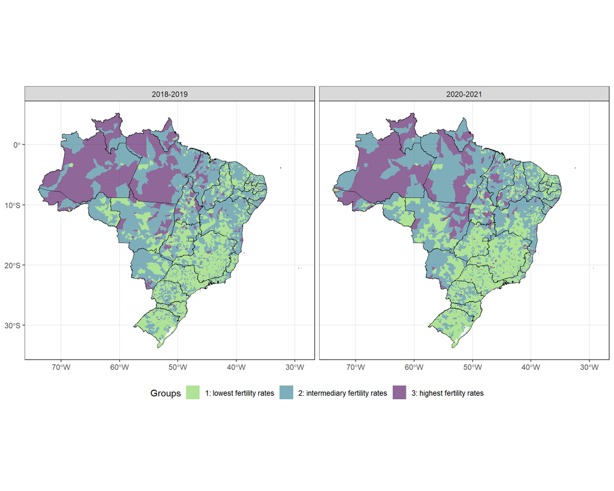

Figure 26: Distribution of groups of municipalities formed by municipalities with similar fertility rate of women aged 10 to 14 years in the pre-pandemic period (on the left) and in the pandemic period (on the right).

```r
# Plotting the map for the 10 to 14 age group
ggplot() +
  geom_sf(data = df_dados_mapa_completo, aes(fill = cluster_10_a_14), color = NA) +
  facet_wrap(vars(periodo)) +
  scale_fill_viridis_d(name = "Groups", end = 0.8, alpha = 0.6, direction = -1) +
  geom_sf(data = df_ufs_sf, fill = NA, linewidth = 0.08, color = "black") +
  theme_bw() +
  theme(legend.position = "bottom")
```

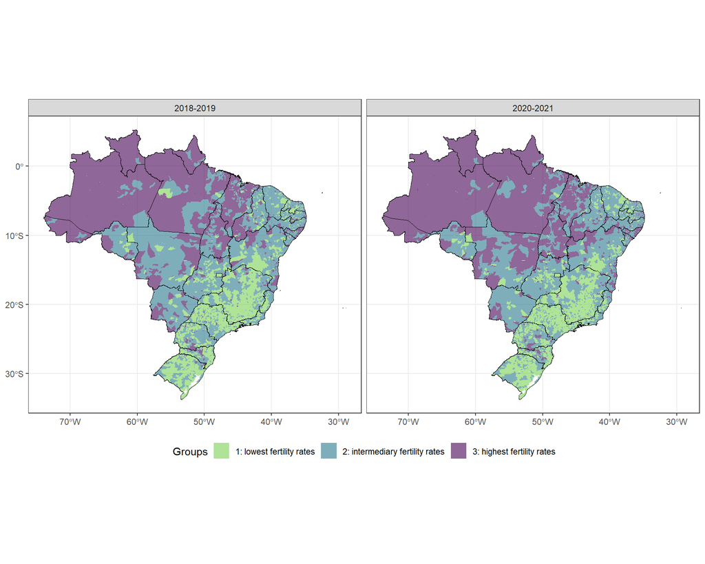

Figure 27: Distribution of groups of municipalities formed by municipalities with similar fertility rate of women aged 15 to 19 years in the pre-pandemic period (on the left) and in the pandemic period (on the right).

```r
# Plotting the map for the 15 to 19 age group
ggplot() +
  geom_sf(data = df_dados_mapa_completo, aes(fill = cluster_15_a_19), color = NA) +
  facet_wrap(vars(periodo)) +
  scale_fill_viridis_d(name = "Groups", end = 0.8, alpha = 0.6, direction = -1) +
  geom_sf(data = df_ufs_sf, fill = NA, linewidth = 0.08, color = "black") +
  theme_bw() +
  theme(legend.position = "bottom")
```

## Summary tables

```r
# Creating a function that creates a table with the summary measures
cria_tabelas <- function(variaveis, df, var_grupos, label_tabela, faixa_etaria, periodo) {
  grupos <- levels(df[[var_grupos]])

  for (variavel in variaveis) {
    tabela <- kable(
      data.frame(
        grupo = grupos,
        n = unlist(lapply(grupos, function(grupo) df[df[[var_grupos]] == grupo, ] |> nrow())),
        minimo = round(unlist(lapply(grupos, function(grupo) df[df[[var_grupos]] == grupo, ] |> pull(variavel) |> min(na.rm = TRUE))), 2),
        primeiro_qt = round(unlist(lapply(grupos, function(grupo) df[df[[var_grupos]] == grupo, ] |> pull(variavel) |> quantile(0.25, na.rm = TRUE))), 2),
        media = round(unlist(lapply(grupos, function(grupo) df[df[[var_grupos]] == grupo, ] |> pull(variavel) |> mean(na.rm = TRUE))), 2),
        mediana = round(unlist(lapply(grupos, function(grupo) df[df[[var_grupos]] == grupo, ] |> pull(variavel) |> median(na.rm = TRUE))), 2),
        dp = round(unlist(lapply(grupos, function(grupo) df[df[[var_grupos]] == grupo, ] |> pull(variavel) |> sd(na.rm = TRUE))), 2),
        terceiro_qt = round(unlist(lapply(grupos, function(grupo) df[df[[var_grupos]] == grupo, ] |> pull(variavel) |> quantile(0.75, na.rm = TRUE))), 2),
        maximo = round(unlist(lapply(grupos, function(grupo) df[df[[var_grupos]] == grupo, ] |> pull(variavel) |> max(na.rm = TRUE))), 2)
      ),
      align = "cccccccc",
      col.names = c("Grupo (cluster)", "n", "Mín.", "1º Quartil", "Média", "Mediana", "D.P.", "3º Quartil", "Máx."),
      caption = HTML(ifelse(variavel == variaveis[1], paste0(glue::glue("Medidas resumo das variáveis de interesse para os grupos de municípios agrupados pela taxa de fecundidade de mulheres {faixa_etaria} (por mil) no período de {periodo}. <br><br>"), variavel), variavel)),
      label = ifelse(variavel == variaveis[1], paste0("tabela", label_tabela), NA)
    )

    print(tabela)
  }
}
nomes_variaveis1 <- c("idhm", "cobertura_ab", "porc_exclusivas_sus", "tx_fecundidade_10_a_14")
nomes_variaveis2 <- c("idhm", "cobertura_ab", "porc_exclusivas_sus", "tx_fecundidade_15_a_19")
```

### For the 10 to 14 age group

#### 2018-2019

```r
# Creating the summary tables for the 10 to 14 age group for the 2018-2019 period
cria_tabelas(
  df = df_indicadores_18_19, var_grupos = "cluster_10_a_14", label_tabela = "1",
  faixa_etaria = "aged 10 to 14", variaveis = nomes_variaveis1, periodo = "2018 to 2019"
)
```

Table 3: Medidas resumo das variáveis de interesse para os grupos de municípios agrupados pela taxa de fecundidade de mulheres aged 10 to 14 (por mil) no período de 2018 to 2019. idhm

| Grupo (cluster) | n | Mín. | 1º Quartil | Média | Mediana | D.P. | 3º Quartil | Máx. |
| --- | --- | --- | --- | --- | --- | --- | --- | --- |
| 1: lowest fertility rates | 3012 | 0.48 | 0.64 | 0.68 | 0.70 | 0.07 | 0.74 | 0.86 |
| 2: intermediary fertility rates | 2162 | 0.42 | 0.58 | 0.63 | 0.63 | 0.06 | 0.69 | 0.77 |
| 3: highest fertility rates | 396 | 0.44 | 0.56 | 0.61 | 0.60 | 0.07 | 0.66 | 0.76 |

cobertura_ab

| Grupo (cluster) | n | Mín. | 1º Quartil | Média | Mediana | D.P. | 3º Quartil | Máx. |
| --- | --- | --- | --- | --- | --- | --- | --- | --- |
| 1: lowest fertility rates | 3012 | 0 | 90.80 | 91.44 | 99.8 | 16.07 | 100 | 100 |
| 2: intermediary fertility rates | 2162 | 0 | 93.90 | 93.38 | 100.0 | 13.30 | 100 | 100 |
| 3: highest fertility rates | 396 | 25 | 93.83 | 94.08 | 100.0 | 12.06 | 100 | 100 |

porc_exclusivas_sus

| Grupo (cluster) | n | Mín. | 1º Quartil | Média | Mediana | D.P. | 3º Quartil | Máx. |
| --- | --- | --- | --- | --- | --- | --- | --- | --- |
| 1: lowest fertility rates | 3012 | 0 | 2.3 | 11.94 | 7.4 | 12.36 | 18.20 | 84.3 |
| 2: intermediary fertility rates | 2162 | 0 | 1.0 | 6.16 | 2.6 | 8.62 | 7.80 | 98.5 |
| 3: highest fertility rates | 396 | 0 | 0.5 | 2.94 | 1.2 | 4.24 | 3.42 | 24.8 |

tx_fecundidade_10_a_14

| Grupo (cluster) | n | Mín. | 1º Quartil | Média | Mediana | D.P. | 3º Quartil | Máx. |
| --- | --- | --- | --- | --- | --- | --- | --- | --- |
| 1: lowest fertility rates | 3012 | 0.0 | 0.0 | 0.94 | 0.9 | 0.95 | 1.80 | 2.6 |
| 2: intermediary fertility rates | 2162 | 2.7 | 3.3 | 4.40 | 4.2 | 1.26 | 5.30 | 7.3 |
| 3: highest fertility rates | 396 | 7.4 | 8.1 | 10.34 | 9.1 | 4.28 | 10.93 | 50.6 |

#### 2020-2021

```r
# Creating the summary tables for the 10 to 14 age group for the 2020-2021 period
cria_tabelas(
  df = df_indicadores_20_21, var_grupos = "cluster_10_a_14", label_tabela = "2",
  faixa_etaria = "aged 10 to 14", variaveis = nomes_variaveis1, periodo = "2020 to 2021"
)
```

Table 4: Medidas resumo das variáveis de interesse para os grupos de municípios agrupados pela taxa de fecundidade de mulheres aged 10 to 14 (por mil) no período de 2020 to 2021. idhm

| Grupo (cluster) | n | Mín. | 1º Quartil | Média | Mediana | D.P. | 3º Quartil | Máx. |
| --- | --- | --- | --- | --- | --- | --- | --- | --- |
| 1: lowest fertility rates | 3274 | 0.45 | 0.63 | 0.68 | 0.70 | 0.07 | 0.73 | 0.86 |
| 2: intermediary fertility rates | 1986 | 0.45 | 0.58 | 0.63 | 0.62 | 0.06 | 0.68 | 0.81 |
| 3: highest fertility rates | 310 | 0.42 | 0.55 | 0.60 | 0.59 | 0.07 | 0.66 | 0.76 |

cobertura_ab

| Grupo (cluster) | n | Mín. | 1º Quartil | Média | Mediana | D.P. | 3º Quartil | Máx. |
| --- | --- | --- | --- | --- | --- | --- | --- | --- |
| 1: lowest fertility rates | 3274 | 21.6 | 89.9 | 91.77 | 100 | 14.69 | 100 | 100 |
| 2: intermediary fertility rates | 1986 | 30.0 | 96.4 | 95.31 | 100 | 10.09 | 100 | 100 |
| 3: highest fertility rates | 310 | 43.5 | 95.7 | 94.89 | 100 | 10.59 | 100 | 100 |

porc_exclusivas_sus

| Grupo (cluster) | n | Mín. | 1º Quartil | Média | Mediana | D.P. | 3º Quartil | Máx. |
| --- | --- | --- | --- | --- | --- | --- | --- | --- |
| 1: lowest fertility rates | 3274 | 0 | 2.5 | 12.42 | 8.1 | 12.28 | 18.88 | 76.2 |
| 2: intermediary fertility rates | 1986 | 0 | 0.9 | 5.77 | 2.4 | 8.08 | 7.20 | 98.5 |
| 3: highest fertility rates | 310 | 0 | 0.4 | 3.57 | 1.3 | 5.64 | 4.30 | 50.1 |

tx_fecundidade_10_a_14

| Grupo (cluster) | n | Mín. | 1º Quartil | Média | Mediana | D.P. | 3º Quartil | Máx. |
| --- | --- | --- | --- | --- | --- | --- | --- | --- |
| 1: lowest fertility rates | 3274 | 0.0 | 0.00 | 0.90 | 0.8 | 0.93 | 1.7 | 2.6 |
| 2: intermediary fertility rates | 1986 | 2.7 | 3.30 | 4.44 | 4.2 | 1.32 | 5.4 | 7.7 |
| 3: highest fertility rates | 310 | 7.8 | 8.53 | 11.14 | 9.6 | 4.24 | 12.0 | 40.3 |

### For the 15 to 19 age group

#### 2018-2019

```r
# Creating the summary tables for the 15 to 19 age group for the 2018-2019 period
cria_tabelas(
  df = df_indicadores_18_19, var_grupos = "cluster_15_a_19", label_tabela = "3",
  faixa_etaria = "aged 15 to 19", variaveis = nomes_variaveis2, periodo = "2018 to 2019"
)
```

Table 5: Medidas resumo das variáveis de interesse para os grupos de municípios agrupados pela taxa de fecundidade de mulheres aged 15 to 19 (por mil) no período de 2018 to 2019. idhm

| Grupo (cluster) | n | Mín. | 1º Quartil | Média | Mediana | D.P. | 3º Quartil | Máx. |
| --- | --- | --- | --- | --- | --- | --- | --- | --- |
| 1: lowest fertility rates | 2357 | 0.48 | 0.66 | 0.70 | 0.71 | 0.06 | 0.74 | 0.86 |
| 2: intermediary fertility rates | 2466 | 0.45 | 0.59 | 0.64 | 0.64 | 0.06 | 0.70 | 0.78 |
| 3: highest fertility rates | 747 | 0.42 | 0.56 | 0.60 | 0.59 | 0.06 | 0.64 | 0.77 |

cobertura_ab

| Grupo (cluster) | n | Mín. | 1º Quartil | Média | Mediana | D.P. | 3º Quartil | Máx. |
| --- | --- | --- | --- | --- | --- | --- | --- | --- |
| 1: lowest fertility rates | 2357 | 0.0 | 89.70 | 90.95 | 99.8 | 16.68 | 100 | 100 |
| 2: intermediary fertility rates | 2466 | 0.0 | 93.80 | 93.47 | 100.0 | 13.15 | 100 | 100 |
| 3: highest fertility rates | 747 | 19.8 | 93.85 | 93.33 | 100.0 | 13.35 | 100 | 100 |

porc_exclusivas_sus

| Grupo (cluster) | n | Mín. | 1º Quartil | Média | Mediana | D.P. | 3º Quartil | Máx. |
| --- | --- | --- | --- | --- | --- | --- | --- | --- |
| 1: lowest fertility rates | 2357 | 0 | 3.0 | 13.44 | 8.7 | 13.01 | 20.6 | 84.3 |
| 2: intermediary fertility rates | 2466 | 0 | 1.2 | 6.79 | 3.2 | 8.60 | 9.3 | 98.5 |
| 3: highest fertility rates | 747 | 0 | 0.4 | 2.68 | 1.1 | 4.66 | 2.9 | 61.6 |

tx_fecundidade_15_a_19

| Grupo (cluster) | n | Mín. | 1º Quartil | Média | Mediana | D.P. | 3º Quartil | Máx. |
| --- | --- | --- | --- | --- | --- | --- | --- | --- |
| 1: lowest fertility rates | 2357 | 0.0 | 30.1 | 35.44 | 37.2 | 9.49 | 42.90 | 48.3 |
| 2: intermediary fertility rates | 2466 | 48.4 | 53.8 | 61.25 | 60.2 | 8.57 | 67.97 | 78.9 |
| 3: highest fertility rates | 747 | 79.1 | 84.6 | 96.83 | 91.4 | 17.69 | 103.10 | 213.9 |

#### 2020-2021

```r
# Creating the summary tables for the 15 to 19 age group for the 2020-2021 period
cria_tabelas(
  df = df_indicadores_20_21, var_grupos = "cluster_15_a_19", label_tabela = "4",
  faixa_etaria = "aged 15 to 19", variaveis = nomes_variaveis2, periodo = "2020 to 2021"
)
```

Table 6: Medidas resumo das variáveis de interesse para os grupos de municípios agrupados pela taxa de fecundidade de mulheres aged 15 to 19 (por mil) no período de 2020 to 2021. idhm

| Grupo (cluster) | n | Mín. | 1º Quartil | Média | Mediana | D.P. | 3º Quartil | Máx. |
| --- | --- | --- | --- | --- | --- | --- | --- | --- |
| 1: lowest fertility rates | 2244 | 0.49 | 0.66 | 0.70 | 0.71 | 0.06 | 0.75 | 0.86 |
| 2: intermediary fertility rates | 2499 | 0.48 | 0.59 | 0.64 | 0.64 | 0.06 | 0.70 | 0.85 |
| 3: highest fertility rates | 827 | 0.42 | 0.56 | 0.60 | 0.59 | 0.06 | 0.64 | 0.75 |

cobertura_ab

| Grupo (cluster) | n | Mín. | 1º Quartil | Média | Mediana | D.P. | 3º Quartil | Máx. |
| --- | --- | --- | --- | --- | --- | --- | --- | --- |
| 1: lowest fertility rates | 2244 | 21.6 | 87.27 | 90.62 | 99.55 | 15.69 | 100 | 100 |
| 2: intermediary fertility rates | 2499 | 30.9 | 96.20 | 95.09 | 100.00 | 10.63 | 100 | 100 |
| 3: highest fertility rates | 827 | 35.8 | 94.75 | 94.56 | 100.00 | 10.97 | 100 | 100 |

porc_exclusivas_sus

| Grupo (cluster) | n | Mín. | 1º Quartil | Média | Mediana | D.P. | 3º Quartil | Máx. |
| --- | --- | --- | --- | --- | --- | --- | --- | --- |
| 1: lowest fertility rates | 2244 | 0 | 3.9 | 14.75 | 10.75 | 13.15 | 22.83 | 74.5 |
| 2: intermediary fertility rates | 2499 | 0 | 1.2 | 7.12 | 3.70 | 8.52 | 10.05 | 98.5 |
| 3: highest fertility rates | 827 | 0 | 0.5 | 2.83 | 1.20 | 4.57 | 3.00 | 46.6 |

tx_fecundidade_15_a_19

| Grupo (cluster) | n | Mín. | 1º Quartil | Média | Mediana | D.P. | 3º Quartil | Máx. |
| --- | --- | --- | --- | --- | --- | --- | --- | --- |
| 1: lowest fertility rates | 2244 | 0.0 | 25.8 | 30.68 | 32.4 | 8.80 | 37.6 | 42.5 |
| 2: intermediary fertility rates | 2499 | 42.6 | 47.7 | 54.50 | 53.4 | 8.01 | 60.6 | 71.5 |
| 3: highest fertility rates | 827 | 71.6 | 76.1 | 88.61 | 82.9 | 18.29 | 94.4 | 225.3 |

## Multiple comparisions tables

```r
# Creating a function that creates a table with the multiple comparisions
cria_tabelas_testes <- function(variaveis, df, var_grupos, label_tabela, faixa_etaria, periodo) {
  for (variavel in variaveis) {

    formula <- as.formula(glue::glue("{variavel} ~ {var_grupos}"))
    resultados_dunn <- dunn_test(data = df, formula = formula, p.adjust.method = "bonferroni")

    # Calcula a medida de efeito d de Cohen
    efeito_d <- cohens_d(data = df, formula = formula)

    monta_linhas <- function(num_grupo) {
      paste(
        -1 * round(resultados_dunn$statistic[which(resultados_dunn$group1 == unique(resultados_dunn$group1)[num_grupo])], 3),
        "(Z) <br>",
        ifelse(
          round(resultados_dunn$p.adj[which(resultados_dunn$group1 == unique(resultados_dunn$group1)[num_grupo])], 3) < 0.05,
          ifelse(
            round(resultados_dunn$p.adj[which(resultados_dunn$group1 == unique(resultados_dunn$group1)[num_grupo])], 3) == 0,
            "< 0.001*",
            paste0(round(resultados_dunn$p.adj[which(resultados_dunn$group1 == unique(resultados_dunn$group1)[num_grupo])], 3), "*")
          ),
          round(resultados_dunn$p.adj[which(resultados_dunn$group1 == unique(resultados_dunn$group1)[num_grupo])], 3)
        ),
        "(valor-p) <br>",
        round(efeito_d$effsize[efeito_d$group1 == unique(efeito_d$group1)[num_grupo]], 3),
        "(D de Cohen)"
      )
    }

    df_teste <- data.frame(
      grupo1 = monta_linhas(1),
      grupo2 = c(rep("", 1), monta_linhas(2)),
      row.names = unique(resultados_dunn$group2)
    )

    colnames(df_teste) <- unique(resultados_dunn$group1)

    tabela <- kable(
      df_teste,
      align = c("cc"),
      caption = HTML(ifelse(variavel == variaveis[1], paste0(glue::glue("Results of Dunn's tests (with Bonferroni correction) for multiple comparisons between pairs of groups of municipalities grouped by the fertility rate of women {faixa_etaria} (per thousand) in the period {periodo}. <br><br>"), variavel), variavel)),
      label = ifelse(variavel == variaveis[1], paste0("tabela-comparacoes-", label_tabela), NA)
    )

    print(tabela)
  }
}
nomes_variaveis1 <- c("idhm", "cobertura_ab", "porc_exclusivas_sus", "tx_fecundidade_10_a_14")
nomes_variaveis2 <- c("idhm", "cobertura_ab", "porc_exclusivas_sus", "tx_fecundidade_15_a_19")
```

### For the 10 to 14 age group

#### 2018-2019

```r
# Creating the multiple comparisions tables for the 10 to 14 age group and 2018-2019 period
cria_tabelas_testes(
  df = df_indicadores_18_19, var_grupos = "cluster_10_a_14", label_tabela = "1",
  faixa_etaria = "aged 10 to 14", variaveis = nomes_variaveis1, periodo = "2018 to 2019"
)
```

Table 7: Results of Dunn’s tests (with Bonferroni correction) for multiple comparisons between pairs of groups of municipalities grouped by the fertility rate of women aged 10 to 14 (per thousand) in the period 2018 to 2019. idhm

|  | 1: lowest fertility rates | 2: intermediary fertility rates |
| --- | --- | --- |
| 2: intermediary fertility rates | 24.864 (Z) < 0.001* (valor-p) 0.757 (D de Cohen) |  |
| 3: highest fertility rates | 19.661 (Z) < 0.001* (valor-p) 1.171 (D de Cohen) | 6.402 (Z) < 0.001* (valor-p) 0.431 (D de Cohen) |

cobertura_ab

|  | 1: lowest fertility rates | 2: intermediary fertility rates |
| --- | --- | --- |
| 2: intermediary fertility rates | -3.749 (Z) 0.001* (valor-p) -0.132 (D de Cohen) |  |
| 3: highest fertility rates | -3.02 (Z) 0.008* (valor-p) -0.186 (D de Cohen) | -1.02 (Z) 0.923 (valor-p) -0.055 (D de Cohen) |

porc_exclusivas_sus

|  | 1: lowest fertility rates | 2: intermediary fertility rates |
| --- | --- | --- |
| 2: intermediary fertility rates | 20.206 (Z) < 0.001* (valor-p) 0.543 (D de Cohen) |  |
| 3: highest fertility rates | 19.258 (Z) < 0.001* (valor-p) 0.974 (D de Cohen) | 8.412 (Z) < 0.001* (valor-p) 0.474 (D de Cohen) |

tx_fecundidade_10_a_14

|  | 1: lowest fertility rates | 2: intermediary fertility rates |
| --- | --- | --- |
| 2: intermediary fertility rates | -57.478 (Z) < 0.001* (valor-p) -3.099 (D de Cohen) |  |
| 3: highest fertility rates | -45.295 (Z) < 0.001* (valor-p) -3.033 (D de Cohen) | -14.654 (Z) < 0.001* (valor-p) -1.884 (D de Cohen) |

#### 2020-2021

```r
# Creating the multiple comparisions tables for the 10 to 14 age group and 2020-2021 period
cria_tabelas_testes(
  df = df_indicadores_20_21, var_grupos = "cluster_10_a_14", label_tabela = "2",
  faixa_etaria = "aged 10 to 14", variaveis = nomes_variaveis1, periodo = "2020 to 2021"
)
```

Table 8: Results of Dunn’s tests (with Bonferroni correction) for multiple comparisons between pairs of groups of municipalities grouped by the fertility rate of women aged 10 to 14 (per thousand) in the period 2020 to 2021. idhm

|  | 1: lowest fertility rates | 2: intermediary fertility rates |
| --- | --- | --- |
| 2: intermediary fertility rates | 27.357 (Z) < 0.001* (valor-p) 0.85 (D de Cohen) |  |
| 3: highest fertility rates | 17.661 (Z) < 0.001* (valor-p) 1.159 (D de Cohen) | 4.439 (Z) < 0.001* (valor-p) 0.361 (D de Cohen) |

cobertura_ab

|  | 1: lowest fertility rates | 2: intermediary fertility rates |
| --- | --- | --- |
| 2: intermediary fertility rates | -7.638 (Z) < 0.001* (valor-p) -0.281 (D de Cohen) |  |
| 3: highest fertility rates | -3.145 (Z) 0.005* (valor-p) -0.243 (D de Cohen) | 0.497 (Z) 1 (valor-p) 0.041 (D de Cohen) |

porc_exclusivas_sus

|  | 1: lowest fertility rates | 2: intermediary fertility rates |
| --- | --- | --- |
| 2: intermediary fertility rates | 23.519 (Z) < 0.001* (valor-p) 0.639 (D de Cohen) |  |
| 3: highest fertility rates | 16.742 (Z) < 0.001* (valor-p) 0.925 (D de Cohen) | 5.338 (Z) < 0.001* (valor-p) 0.316 (D de Cohen) |

tx_fecundidade_10_a_14

|  | 1: lowest fertility rates | 2: intermediary fertility rates |
| --- | --- | --- |
| 2: intermediary fertility rates | -58.04 (Z) < 0.001* (valor-p) -3.103 (D de Cohen) |  |
| 3: highest fertility rates | -39.905 (Z) < 0.001* (valor-p) -3.333 (D de Cohen) | -11.799 (Z) < 0.001* (valor-p) -2.132 (D de Cohen) |

#### For the 15 to 19 age group

```r
# Creating the multiple comparisions tables for the 15 to 19 age group and 2018-2019 period
cria_tabelas_testes(
  df = df_indicadores_18_19, var_grupos = "cluster_15_a_19", label_tabela = "3",
  faixa_etaria = "aged 15 to 19", variaveis = nomes_variaveis2, periodo = "2018 to 2019"
)
```

Table 9: Results of Dunn’s tests (with Bonferroni correction) for multiple comparisons between pairs of groups of municipalities grouped by the fertility rate of women aged 15 to 19 (per thousand) in the period 2018 to 2019. idhm

|  | 1: lowest fertility rates | 2: intermediary fertility rates |
| --- | --- | --- |
| 2: intermediary fertility rates | 25.777 (Z) < 0.001* (valor-p) 0.821 (D de Cohen) |  |
| 3: highest fertility rates | 31.829 (Z) < 0.001* (valor-p) 1.595 (D de Cohen) | 14.211 (Z) < 0.001* (valor-p) 0.742 (D de Cohen) |

cobertura_ab

|  | 1: lowest fertility rates | 2: intermediary fertility rates |
| --- | --- | --- |
| 2: intermediary fertility rates | -3.922 (Z) < 0.001* (valor-p) -0.168 (D de Cohen) |  |
| 3: highest fertility rates | -3.63 (Z) 0.001* (valor-p) -0.158 (D de Cohen) | -0.944 (Z) 1 (valor-p) 0.011 (D de Cohen) |

porc_exclusivas_sus

|  | 1: lowest fertility rates | 2: intermediary fertility rates |
| --- | --- | --- |
| 2: intermediary fertility rates | 20.071 (Z) < 0.001* (valor-p) 0.603 (D de Cohen) |  |
| 3: highest fertility rates | 28.976 (Z) < 0.001* (valor-p) 1.101 (D de Cohen) | 15.287 (Z) < 0.001* (valor-p) 0.595 (D de Cohen) |

tx_fecundidade_15_a_19

|  | 1: lowest fertility rates | 2: intermediary fertility rates |
| --- | --- | --- |
| 2: intermediary fertility rates | -52.06 (Z) < 0.001* (valor-p) -2.856 (D de Cohen) |  |
| 3: highest fertility rates | -59.509 (Z) < 0.001* (valor-p) -4.326 (D de Cohen) | -23.921 (Z) < 0.001* (valor-p) -2.56 (D de Cohen) |

```r
# Creating the multiple comparisions tables for the 15 to 19 age group and 2020-2021 period
cria_tabelas_testes(
  df = df_indicadores_20_21, var_grupos = "cluster_15_a_19", label_tabela = "4",
  faixa_etaria = "aged 15 to 19", variaveis = nomes_variaveis2, periodo = "2020 to 2021"
)
```

Table 10: Results of Dunn’s tests (with Bonferroni correction) for multiple comparisons between pairs of groups of municipalities grouped by the fertility rate of women aged 15 to 19 (per thousand) in the period 2020 to 2021. idhm

|  | 1: lowest fertility rates | 2: intermediary fertility rates |
| --- | --- | --- |
| 2: intermediary fertility rates | 27.995 (Z) < 0.001* (valor-p) 0.922 (D de Cohen) |  |
| 3: highest fertility rates | 35.326 (Z) < 0.001* (valor-p) 1.764 (D de Cohen) | 15.53 (Z) < 0.001* (valor-p) 0.791 (D de Cohen) |

cobertura_ab

|  | 1: lowest fertility rates | 2: intermediary fertility rates |
| --- | --- | --- |
| 2: intermediary fertility rates | -9.895 (Z) < 0.001* (valor-p) -0.333 (D de Cohen) |  |
| 3: highest fertility rates | -5.593 (Z) < 0.001* (valor-p) -0.291 (D de Cohen) | 1.502 (Z) 0.399 (valor-p) 0.049 (D de Cohen) |

porc_exclusivas_sus

|  | 1: lowest fertility rates | 2: intermediary fertility rates |
| --- | --- | --- |
| 2: intermediary fertility rates | 22.25 (Z) < 0.001* (valor-p) 0.689 (D de Cohen) |  |
| 3: highest fertility rates | 31.802 (Z) < 0.001* (valor-p) 1.21 (D de Cohen) | 16.117 (Z) < 0.001* (valor-p) 0.626 (D de Cohen) |

tx_fecundidade_15_a_19

|  | 1: lowest fertility rates | 2: intermediary fertility rates |
| --- | --- | --- |
| 2: intermediary fertility rates | -50.709 (Z) < 0.001* (valor-p) -2.831 (D de Cohen) |  |
| 3: highest fertility rates | -61.675 (Z) < 0.001* (valor-p) -4.037 (D de Cohen) | -25.779 (Z) < 0.001* (valor-p) -2.416 (D de Cohen) |

# Phase 3: GAMLSS modeling

```r
# Reading and manipulating the data
df_indicadores <- read.csv("databases/data_fertility_rates_article.csv") |>
  filter(ano >= 2018 & ano <= 2021) |>
  mutate(
    codmunres = as.character(codmunres),
    tx_fecundidade_menor_20 = round(nvm_10_a_19 / pop_feminina_10_a_19 * 1000, 1),
    cobertura_ab = round(media_cobertura_ab / populacao_total * 100, 1),
    porc_exclusivas_sus = round((pop_feminina_10_a_49 - pop_fem_10_49_com_plano_saude) / pop_feminina_10_a_49 * 100, 1),
    pandemia = factor(ifelse(ano < 2020, "before", "during"), levels = c("before", "during")),
    ano = as.factor(ano)
  ) |>
  drop_na() # There are 5 municipalities without the HDI-M information
```

This stage of the article aimed to find and interpret a regression model that would best explain the fertility rate in women under 20 years of age in Brazilian municipalities, initially based on covariates such as the reference year, the HDI-M, the population coverage of Primary Care, the percentage of women aged 10 to 49 who are exclusive users of the SUS, and a variable indicating the Covid-19 pandemic. Although the interest was, most likely, in modeling the entire period from 2012 to 2021, we had to make the decision to restrict the analysis period to the years 2018 to 2021, since models that considered the entire period did not present appropriate adjustments. With this consideration in mind, a brief description of the variables that will be considered in this phase can be seen in the table below.

Table 11: Description of the variables considered for the GAMLSS modeling.

[output not shown]

## About regression

Initial attempts to find regression models always involve, of course, adjustments to linear regression models, within which we make assumptions that imply the normality of the response variable in question. The histogram of the fertility rate in women under 20 years old, presented in the figure below, shows, however, a relatively common scenario in which the response variable of the problem **does not** appear to be normally distributed, which can be noted by the strong asymmetry to the right present in the graph. In this scenario, linear regression models have their assumptions violated and, therefore, their conclusions are no longer valid.

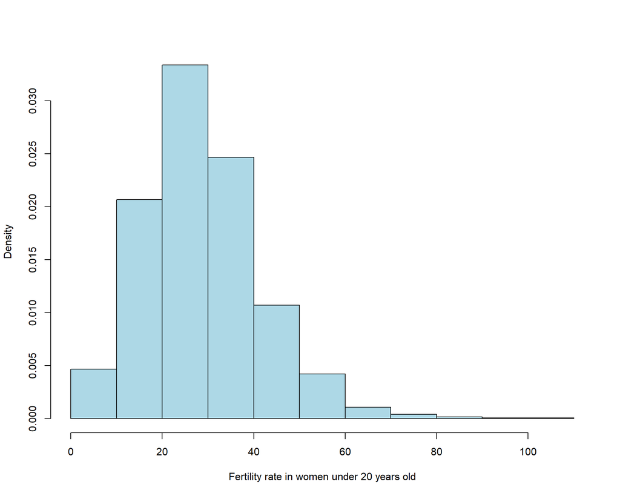

Figure 28: Histogram of the fertility rate in women under 20 years of age in 2019.

```r
hist(
  df_indicadores$tx_fecundidade_menor_20[which(df_indicadores$ano == "2019")], freq = FALSE,
  col = "lightblue",
  main = "",
  xlab = "Fertility rate in women under 20 years old",
  ylab = "Density"
)
```

Thus, to overcome this problem, we expanded our search for regression models to GAMLSS models (R. A. Rigby and D. M. Stasinopoulos 2005), which allow us to choose from a range of different distributions for the response variable and which have as a major differential the fact that they allow us to separately model the parameters of location (related to the mean of the distribution), scale (related to the variance of the distribution) and shape (related to the asymmetry and kurtosis of the distribution). We adjusted and verified the adequacy of a series of different GAMLSS models, and decided to discuss in this work the models that: 1) assume that the response variable follows a skew t type 4 distribution, which allows us to model all four parameters discussed; and 2) assume that the response variable follows a zero-adjusted gamma distribution (ZAGA), which allows us to model the parameters of location, scale and the shape parameter related to the asymmetry of the distribution. It is important to note that, to avoid multicollinearity problems, we decided not to include in the analysis the covariate of the percentage of women aged 10 to 49 who are exclusive users of the SUS, since, as can be seen in the correlogram shown in the figure below, the variables `porc_exclusivas_sus` and `idhm` have a considerable linear correlation.

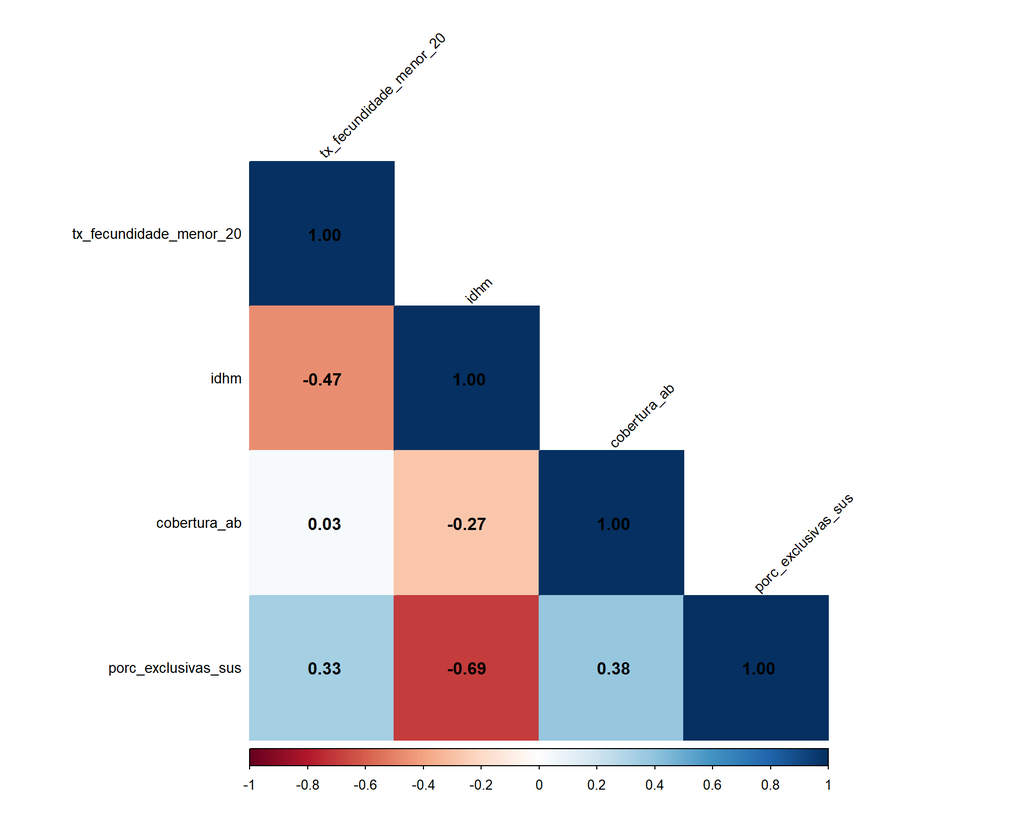

Figure 29: Pearson correlations between the variables in the dataset in 2019.

```r
## Criando os correlogramas
corrplot(
  cor(
    df_indicadores |> filter(ano == "2019") |> dplyr::select_at(vars(starts_with("tx") | "idhm" | "cobertura_ab", "porc_exclusivas_sus")),
    use = "complete.obs", method = "pearson"
  ),
  method = "color",
  type = "lower",
  addCoef.col = "black",
  tl.col = "black",
  tl.srt = 45,
  tl.cex = 0.85,
  diag = TRUE,
  cl.pos = "b",
  mar = c(0, 0, 1.5, 0)
)
```

## Fitting the models

Since GAMLSS models give us the freedom to model separately the location, scale and shape parameters of the distribution, a very large set of different models for a chosen distribution can be fitted. Therefore, after assuming a distribution for the response variable, we need to find the best model among all those that could be fitted considering this chosen distribution. To do this, we used two strategies described by Stasinopoulos et al. (2017, 397), which, in short, use stepwise selection methods and 1) allow different sets of covariates to be chosen to model each parameter of the distribution; or 2) force the same covariates to be selected to model all parameters of the distribution. Therefore, for each of the two selected distributions (skew t type 4 and ZAGA), we fitted:

- the full model, which has a random intercept for the reference year and which uses as covariates `coverage_ab`, `idhm`, `pandemic` and their interactions;
- the reduced model chosen by strategy 1;
- the reduced model chosen by strategy 2;
- and a third reduced model, which uses, for the $\mu$ model, only the significant terms of the full model.

To decide whether the reduced models were better than the full model, we used the generalized likelihood ratio test (GLRT) - which, in a simplified way, tests the null hypothesis that the reduced model is better than the full model (against the hypothesis that the full model is better). The **rejection** of the GLR null hypothesis, then, gives us evidence to believe that the reduced model is worse than the full model (which would therefore lead us to choose the full model). If the GLRT null hypothesis was not rejected for all the reduced models, we chose the reduced model that presented the most appropriate residual analysis or the lowest AIC value. Finally, after selecting the best model for each distribution, we chose, between the two selected models, the one that presented the most appropriate residual analysis or the lowest AIC value. All analyses were conducted using functions from the `{gamlss}` package (R. A. Rigby and D. M. Stasinopoulos 2005), available in the R software (R Core Team 2023).

It is important to note that we chose to incorporate a random effect for the reference year to address the issue that observations from the same year are possibly correlated with each other, which violates the basic assumption that the observations are all independent.